# gitolite all-in-one page

# 1 background

## 1.1 Hosting Git Repositories

| Gitolite allows you to setup git hosting on a central server, with fine-grained access control and many more powerful features. | **Looking for the old "Notes on Git" page? Click here**. |
| --- | --- |

### download

Gitolite can be downloaded from `git://github.com/sitaramc/gitolite`.

If your Unix-fu and ssh-fu are good, installing gitolite is as simple as copying your public key over to the hosting user, and running a couple of commands, as the quick install section of the install page shows.

If you're installing via your package manager, make sure you get the correct version; see the install page for details.

### documentation

**New (April 2014): There's a [book on gitolite](http://www.packtpub.com/gitolite-essentials/book) out**. I've received some emails over the years asking where to donate for gitolite to show your appreciation, and I've always refused politely. Well, if you insist... buy the book :-)

Gitolite has a lot of features, and consequently a lot of documentation.

This page (the one you're reading) is the main page. It, as well as most other pages, should have a "Gitolite table of contents" along the right margin (possibly preceded by a "Page table of contents").

If you're not sure where to start, read the main page and the overview page, then look over the rest of the table of contents to decide.

#### (reading order and forward references)

I've tried hard to make the documentation readable in a straight sequence, using the "Gitolite TOC" on the right side. Of course there are places where I have no choice but to refer or link to something that has not been encountered yet, but generally you can ignore those links on a first pass through the documentation.

### troubleshooting

If you're having trouble, please try the following resources first:

- The emergencies page helps with all sorts of install/setup issues, recovering from lost keys and other self-inflicted wounds, lists some common (and some uncommon!) errors and non-standard configs that may trip you up.
- The idiot-proof setup is a very detailed page that shows one fool-proof way to install, as long as you follow instructions faithfully!
- And finally, for specific post-install issues, perhaps the cookbook has a recipe just for you?

### contact and support

#### email

Unless you're reporting what you think is a security issue, please use the mailing list for all communication. (**NOTE**: The first email from a new member is held until I can clear it; subsequent emails from the same email address do not get held up).

- Mailing list for support and general discussion:
  - Subscribe: gitolite+subscribe@googlegroups.com
  - Post: gitolite@googlegroups.com

If you don't want to participate in the discussions and only want to be informed of releases, security announcements, etc., you can subscribe to the announce list. This is a one-way list; only I can post to it.

- Mailing list for announcements and notices:
  - Subscribe: gitolite-announce+subscribe@googlegroups.com

If you think you found a **security issue**, please email me directly: sitaramc@gmail.com or sitaram@atc.tcs.com.

If you wish to send me code, please see the file called CONTRIBUTING in the source distribution.

#### IRC

We're on irc at #gitolite on freenode. I live in India (UTC+0530 time zone), but there are a few regulars (*thanks, guys, you know who you are!*) from other times zones. That said, it's not heavy traffic and you may have to wait a while for an answer, depending on the time of day and day of week.

There are also a few gitolite-knowledgeable people on the git channel #git.

### license

The gitolite software is copyright Sitaram Chamarty and is licensed under the GPL v2; please see the file called COPYING in the source distribution.

This **documentation**, which is maintained separately from the main gitolite source code, is copyright Sitaram Chamarty and is provided under a [Creative Commons Attribution-NonCommercial-ShareAlike 3.0 Unported License](http://creativecommons.org/licenses/by-nc-sa/3.0/).

However, certain parts are contributed by others who may have chosen other licenses; their names and license will be mentioned in the respective files.

Documentation for a software product will naturally contain code examples. I believe that the principle of fair use should cover use of those snippets; see especially factors 3 and 4 in the list of factors [here](http://en.wikipedia.org/wiki/Fair_use#Fair_use_under_United_States_law).

If you're not convinced that it would be fair use, then you may consider those code snippets, as well as associated "comments" if any, to be under the GPLv2 license. Licensing is about intent, and the intent of these examples is that you use them wherever and however you can use gitolite itself.

> **NOTE**: GIT is a trademark of Software Freedom Conservancy and my use of "Gitolite" is under license.

## 1.2 Gitolite Overview

Gitolite allows you to setup git hosting on a central server, with fine-grained access control and many more powerful features.

### 1.2.1 what is gitolite?

Gitolite is an access control layer on top of git. Here are the features that most people see:

- Use a single unix user ("real" user) on the server.
- Provide access to many gitolite users:
  - they are not "real" users,
  - so they do not get shell access.
- Control access to many git repositories:
  - read access controlled at the repo level,
  - and write access controlled at the branch/tag/file/directory level, including who can rewind, create, and delete branches/tags.
- Can be installed without root access, assuming git and perl are already installed.
- Authentication is most commonly done using sshd, but you can also use "smart http" mode if you prefer (this may require root access to setup).

**New (April 2014): There's a [book on gitolite](http://www.packtpub.com/gitolite-essentials/book) out**. I've received some emails over the years asking where to donate for gitolite to show your appreciation, and I've always refused politely. Well, if you insist... buy the book :-)

### 1.2.2 why might you need it?

#### 1.2.2.1 access control

Git by itself does not do any access control -- it relies on the transport medium to do authentication ("who are you?"), and on OS file permissions to do authorisation ("what are you allowed to do?").

Git also comes with a program called "git-shell" which can act as a restricted login shell if you don't want users getting a proper shell. Using this and judicious use of Unix groups, you can allow some people read-only access while others get read-write access, etc. This is probably sufficient if your needs are simple and don't change too often.

However, gitolite does this much better, and offers many more features.

##### 1.2.2.1.1 basic use case

Gitolite is useful in any server that is going to host multiple git repositories, each with many developers, where "anyone can do anything to any repo" is not a good idea. Here're two examples to illustrate.

This first example has 3 repos and 3 developers with different levels of access to each repo. It's a very simple, readable, syntax, and makes it easy to answer questions like "what repos can bob push to" (answer: only 'bar').

```
repo foo
    RW+     =   alice
    RW      =   carol

repo bar
    RW+     =   bob
    R       =   alice

repo baz
    RW+     =   carol
    R       =   alice bob
```

This second example allows different levels of access to different branches and tags for different developers:

```
repo foo
    RW+                         =   alice
    RW  master                  =   bob
    RW+ dev/                    =   bob
    RW  refs/heads/tags/v[0-9]  =   ashok
```

#### 1.2.2.2 other features

Gitolite has many more features, as you might guess from the documentation links on the right. Here's a quick sample:

- Very powerful rule language (decide based on branch/tag name, files/dirs touched, size of changed files, number of changed files, etc.).
- Convenience features for writing the rules (repo groups, user groups, get user group info from LDAP, include files, macros...)
- Highly customisable and scriptable, especially custom commands for users. Many built-in commands and options.
- Powerful and flexible mirroring system.
- Users can create their own repos and set access rights (if you allow them).

#### 1.2.2.3 alternatives to gitolite

##### 1.2.2.3.1 unix permissions and ACLs

If you're a masochist, you could probably do example 1 with Unix permissions and facls. But you can't do example 2 -- git is not designed to allow that!

Here are some other disadvantages of the Unix ACL method:

- Every user needs a userid and password on the server.
- Changing access rights involves complex `usermod -G ...` mumblings (I.e., the "pain" mentioned above is not a one-time pain!)
- *Viewing* the current set of permissions requires running multiple commands to list directories and their permissions/ownerships, users and their group memberships, and then correlating all these manually.
- Auditing historical permissions or permission changes is impossible.

##### 1.2.2.3.2 Gerrit Code Review

The best real alternative to gitolite is Gerrit Code Review. If code review is an essential part of your workflow, you should use Gerrit.

Here're some high level differences between gitolite and Gerrit (as of about mid-2012 or so):

**Size**: 3000+ lines of perl versus of 56,000+ lines of Java

**Architecture**: Gitolite sits on top of "standard" git and openssh, which are assumed to already be installed. Gerrit includes its own git stack (jgit) and sshd (Apache Mina). In Java tradition, they all come bundled together.

(Corollary: As far as I know jgit does not support the same hooks that 'man githooks' talks about).

Gitolite uses a plain text config file; gerrit uses a database.

**User view**: Gitolite is invisible to users except when access is denied. Gerrit is much more visible to devs because of its role in enforcing code review, approvals, and workflow.

On a related note, gitolite does not do anything special with signed or annotated tags, nor does it check author/committer identity. However, it is trivial to add your own code to do either (or if someone contributes it, to just "enable" what ships with gitolite in a disabled state).

##### 1.2.2.3.3 gitorious, gitlab, and others

Anecdotally, gitorious is very hard to install. Comparison with gitolite may be useless because I believe it doesn't have branch/tag level access control. However, I can't confirm or deny this because I can't find any documentation on the website. In addition, the main website hides the source code very well, so you already have a challenge! [The only link I could find was tucked away at the bottom of the About page, in the License section].

Gitorious has several, much newer, competitors offering web-based management, issue tracker, wiki, and so on; try googling for gitlab, gitblit, and rhodecode. Many of them now offer branch level access control as well, to some extent or other.

However, they are unlikely to be as customisable as gitolite is, if you care about that sort of thing.

### 1.2.3 how does it work?

At a very high level, gitolite relies on **sshd** (or **httpd** if you're using the smart http mode) to authenticate the user and supply the username. Based on this, and the command given, it decides whether to allow or deny the request.

[output not shown]

When you install gitolite and setup the user, gitolite sets up ssh to **force** the gitolite-shell command to run first, instead of the command requested:

The 'gitolite-shell' program uses the username supplied by ssh, and the repo name in the command, to decide if the user has write access to the repo or not.

If he does have *some* write access, git-receive-pack is called, but that's not the end of the story. The branch/tag/file(s) he is pushing also need to be checked, and gitolite sets up the update hook on the repo to do that.

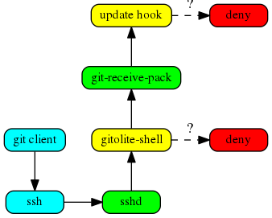

### 1.2.4 who uses it?

[Note that many of the users who are listed in this page may still be using v2.x, presumably because it's working fine for them and there's no compelling reason to upgrade, and I still support v2 at least for critical issues].

> If you're using gitolite and find it very useful in some way, I would love to describe your use of it or add a link to your own description of it here. Of course, you can anonymise it as much as you need to.

The **Fedora Project** controls access to over 10,000 package management repositories accessed by over 1,000 package maintainers [using gitolite](http://lists.fedoraproject.org/pipermail/devel-announce/2010-July/000647.html). This is probably the largest *confirmed* gitolite installation anywhere. The whole "big-config" option back in v2 (in v3 this is the default!) was initially done for them (their config file was so big that without the big-config changes gitolite would just run out of memory and die!).

The **KDE project** [uses](http://community.kde.org/Sysadmin/GitKdeOrgManual) gitolite (in combination with redmine for issue tracking and reviewboard for code review). Apart from the usual access control, the KDE folks are heavy users of the "ad hoc repo creation" features enabled by wildrepos and the accompanying commands. Several of the changes to the "admin defined commands" were also inspired by KDE's needs. See [section 5](http://community.kde.org/Sysadmin/GitKdeOrgManual#Server-side_commands) and [section 6](http://community.kde.org/Sysadmin/GitKdeOrgManual#Personal_repositories) of the above linked page for details.

**Prof. Hiren Patel** of the University of Waterloo is responsible for the existence of the fairly popular "wildrepos" feature. The documentation was pretty much written with his use case in mind, but of course it turns out to be useful for a lot of people, as you can see from the previous para on KDE's use of gitolite.

In fact, he surprised the heck out of me once by saying that if it hadn't been for this feature, he might not have used git itself -- which is a pretty serious compliment if you think about the magnitude of the git project and my little one-man show!

He explains his use of it [here](http://caesr.uwaterloo.ca/wildrepos-in-gitolite/).

**Gentoo Linux** has [just moved](http://archives.gentoo.org/gentoo-dev/msg_2812c9b9e768f64b46360ab17b9d0024.xml) their git repositories from gitosis to gitolite. There are about 200 repositories, some of them are the so called [overlays](http://www.gentoo.org/proj/en/overlays/), official and unofficial/user overlays, plus several developer and project repositories, used by more than 1000 people. That number will be increased in the near future, as they are going to migrate some of their CVS/SVN repositories there, plus they are offering overlays hosting for users as well.

**kernel.org**, the official distribution point for the Linux kernel, is the latest (as of 2011-10) high-visibility installation. According to [this email](http://lkml.org/lkml/2011/9/23/357) to the lkml, kernel.org decided to use gitolite for access controlling their git repos. Their [FAQ entry](http://www.kernel.org/faq/#whygitolite) describes at a high level why they chose gitolite.

This move also prompted the first ever security audit of gitolite by an outside party. Gitolite did great; see [here](http://groups.google.com/group/gitolite/browse_thread/thread/8dc5242052b16d0f) for details. [NOTE: v3 has not had such an audit yet; if you did one, please let me know what you found. If you want to do one and need clarifications on anything or general background let me know].

In addition, kernel.org was responsible for a serious rethink of a few rough edges in gitolite, and smoothing them out was fun (the "playing with gitolite" stuff, making the test suite simpler, "deny" rules for the entire repo).

The **Mageia Project** is [using](http://gitweb.mageia.org/) gitolite 3 to manage its git repositories and access control. The repositories are [defined](http://gitweb.mageia.org/infrastructure/repositories/software/) in yaml files. A tool called [mgagit](http://gitweb.mageia.org/software/infrastructure/mgagit/) has been created and is repsonsible for the generation of the gitolite configuration from the yaml repos definitions, and the extraction of users' ssh keys from an ldap directory into the gitolite configuration.

Gitolite and mgagit are installed using rpm packages and [a puppet module](http://svnweb.mageia.org/adm/puppet/deployment/mgagit/).

A general note: if you see the list of high-profile users above, you will see that gitolite benefits as much as they do; possibly more.

### 1.2.5 license

Please see the license section for details on the licenses for gitolite code and documentation.

> **NOTE**: GIT is a trademark of Software Freedom Conservancy and my use of "Gitolite" is under license.

## 1.3 Concepts, Conventions, and Terminology

I assume you're at least somewhat familiar with **git** itself. If not, the "what you need" page has a list of topics that you should be familiar with.

This page will help newcomers get used to what we're talking about elsewhere. Any time you hear a word or phrase you're not familiar with, this is the page that will help you figure it out.

It also contains a collection of extra background information that some of the main sections may gloss over, such as for example the section on "how does gitolite-admin work?"

### 1.3.1 authentication and authorisation

**Gitolite does not do authentication. It only does authorisation.**

So let's loosely define these words:

> **Authentication** is the process of verifying that you are who you claim to be. An authentication system will establish that I am the user "sitaram" on my work system. The one behind gmail will similarly establish that I am "sitaramc". And so on...

> **Authorisation** is the process of asking what you want to do and deciding if you're allowed to do it or not.

When you use gitolite, it's in one of two modes: ssh mode, or http mode. In ssh mode, your users will authenticate themselves to your server's "sshd" (ssh daemon), while in http mode they will be talking to your web server. A user who fails to authenticate himself will not make it past that step, so gitolite is not even involved.

If authentication succeeds, sshd or httpd will pass control to gitolite, which can then figure out whether to allow you to do whatever it is you want to whatever repo you decided to touch. That's authorisation.

### 1.3.2 ssh mode and http mode

Git allows authenticated remote access using these two mechanisms: ssh and http. Gitolite supports both.

Ssh mode is much easier to install and setup; most systems already have whatever you need, and -- except for creating the "hosting user" -- you don't need to do anything as root. However, your users have to generate an ssh keypair for themselves (using "ssh-keygen") if they don't already have a keypair, and they have to send you the public key (the file ending in ".pub"), which you add to gitolite.

Http mode requires a bit more work in terms of setting things up. Once setup, however, it may be a little easier for your users. Authentication is by username + password, which, although much less secure than RSA keypairs, is conceptually easier for users.

### 1.3.3 the "hosting user"

When you install gitolite in ssh mode, you pick one specific user on the Unix system to be the "hosting user". This is the user whose name goes into the repo URLs your users will be cloning, for example `ssh://git@server/repo`, or the simpler form `git@server:repo`.

If you're wondering how it distinguishes between different users when they are all logging into "git", the ssh page has all that and much more!

*Usually*, this is "git", and that is what we assume in this documentation. However, it can actually be any user on the system, and I think both the Fedora RPM and the Debian DEB use "gitolite", so adjust instructions and examples accordingly. **Unless otherwise stated, everything that we do "on the server" is done in this userid (for ssh mode installations).**

Of course you can have any number of "hosting users", but that's rare.

### 1.3.4 the "logical repo name"

Gitolite refers to repos using a logical repo name, which is whatever name you specified in the gitolite.conf file (described later). The actual repo will be in `$HOME/repositories`, and will have a ".git" suffix. So, for example, the logical repo name "foo" will be `$HOME/repositories/foo.git` on disk, and "bar/baz" will be `$HOME/repositories/bar/baz.git`. The logical repo name is what you must use for all interactions with gitolite (within the conf file, repo name arguments to gitolite commands or API functions, etc.) unless specifically documented otherwise.

One exception: you're allowed to add the ".git" extension in git commands (clone, fetch, push, ls-remote, archive) if you wish, because git itself allows it, and we'd like to be as transparent as possible. The `$HOME/repositories` prefix should never be specified. If you do specify it, and things appear to work, something is wrong!.

### 1.3.5 the special gitolite-admin repo

Gitolite manages git repos. Among them is a repo called "gitolite-admin", which is a very special repository that helps you add and remove users and repos, as well as define access rules for them. **Most day-to-day management of gitolite is done by cloning this repository, making changes to it, and pushing the changes back to the server.**

Specifically, it contains a directory called "keydir", in which you place files with names like "alice.pub", "bob.pub", etc. These are the public keys of you and your users.

It also contains a file called "conf/gitolite.conf", in which you add access rules specifying who gets what level of access to each repo. Here's a simple example:

```
# these lines were already in the file
repo foo
    RW+     =   alice
    RW      =   bob

# these lines were added just now
repo bar
    RW+     =   bob
    R       =   alice
```

Here's what happens when you commit the changes/additions to these files and push them to the server. Since we've already seen the ssh/sshd part of this process (in the overview page), we'll start off from "git-receive-pack":

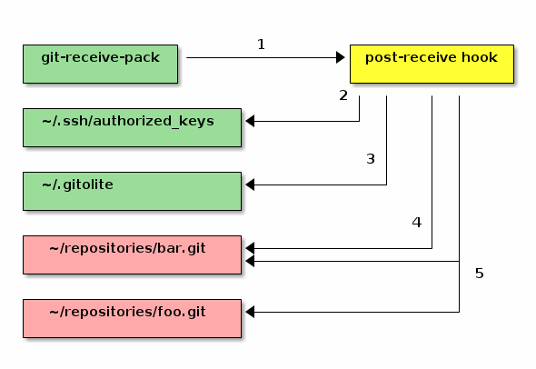

And that, boys and girls, is how gitolite does its thing. That is also why you should NEVER touch any of those files yourself, unless you know what you're doing!

## 1.4 Before you start...

This page talks about what you need to make sure you have before you install gitolite. For most people, this is not a big deal, but please read through it anyway. If you want to make sure, there's a section on trying it out safely.

### 1.4.1 your skills

- If you're installing gitolite, you're a "system admin", like it or not. Since most people use the ssh mode, **ssh** is therefore a necessary skill. Please take the time to learn at least enough to get passwordless access working.
- You also need to be somewhat familiar with git itself. You cannot administer a whole bunch of git repositories if you don't know the basics of git.

  Please make sure you understand at least the following concepts: *bare versus non-bare repos, cloning a repo, making changes and committing them, pushing commits to a 'remote', the special remote called 'origin', difference between a fast-forward push and a rewind push, 'refs' (i.e., branches and tags)*.

  It also helps to understand git's hooks mechanism, git-config, and so on.
- Some familiarity with Unix and shells is probably required.
- Regular expressions are a big part of gitolite in many places but familiarity is not necessary to do *basic* access control.

### 1.4.2 your server

- Any Unix system with a posix compatible "sh" and a **sane** file system.
- Git version 1.6.6 or later.
- Perl 5.8.8 or later (see https://lwn.net/Articles/348084/ if this does not seem to be enough).
- Openssh (almost any version). Optional if you're using smart http.
  - **IMPORTANT**: although a default openssh config will not do this (AFAIK), **do not** allow the user to set environment variables if you care about security at all.
- A dedicated Unix userid to be the hosting user, usually "git" but it can be any user, even your own normal one. (If you're using an RPM/DEB the install probably created one called "gitolite").

### 1.4.3 you and your users' clients

- Openssh client.
- Git 1.6.6 or later. Almost any git client will work, as long as it knows how to use ssh keys and send the right one along.

### 1.4.4 cautions and caveats

**Please take note of the following points**:

- If you're bringing existing repos into gitolite, please see this first.
- Gitolite expects all the directories and files it manages/uses to be owned by the hosting user and not have strange permissions and ownerships.
- Gitolite does NOT like it if you fiddle with files and directories it cares about in any way except as directed in the documentation.
- Gitolite depends on several system-installed packages: openssh, git, perl, sh being the main ones. They should all be configured sensibly and with most of the normal defaults. (For example, if your sshd config says the authorized keys file should be placed in some directory other than the default, expect trouble).

(For your entertainment, here are some requests I have refused over the years).

### 1.4.5 trying out gitolite safely

If you're not sure if gitolite is right for you or your system, it's easy to take it for a trial run, in ssh mode, and play with all of its features (except mirroring). This is very safe, and does not affect anything on your system permanently.

**WARNING: this will clobber these files and directories in your `$HOME`. Ideally, you should use a throwaway userid**.

Just create a **throw-away userid**, log in to it, then run these commands:

```
git clone git://github.com/sitaramc/gitolite
cd gitolite
prove t/ssh*
```

You will get an error that forces you to read `t/README` and set an env var before the test can proceed. This is intentional; I've had people who don't pay attention to the "data loss" warning, and then complain that it was not prominent enough. Forcing them to read a much smaller page appears to focus their attention better!

If it doesn't work, re-read this page to see if you may have missed something that gitolite requires, or ask for support.

If it works, you get a gitolite installation with 7 gitolite users ("admin", and "u1" through "u6").

Don't forget that the client and the server are all on the same user on the same machine; we're *simulating* 7 gitolite users using ssh keys! (How? Maybe `~/.ssh/config` will give you a hint).

URLs look like `user:repo`, so for example you can clone the admin repo by `git clone admin:gitolite-admin`. Remote commands look like `ssh u1 info`.

So start by cloning the admin repo, and try out whatever you want!

# 2 basics

## 2.1 install and setup

**NOTE**: this page is about an ssh mode installation. There's a different page for http mode installation if you need that.

This page talks about installing the software manually (i.e., not using a package manager) and setting it up. The install step gets the code to where you want it. The setup step creates the files and directories gitolite needs, including the special gitolite-admin repo, and makes you an administrator so you can manage it remotely.

If you install gitolite using a package manager, you should check your distro-standard mechanisms or distro-supplied documentation for how to complete the installation.

**NOTE** on package manager installs: make sure you get gitolite **v3.x**. The correct package you want may be called "gitolite3", even though "gitolite" also exists. If you want to know what the latest gitolite version is, the gitolite CHANGELOG will tell you.

**NOTE** on upgrades from v1 or v2: upgrading from v1 or v2 is reasonably easy, but, sadly, cannot be automated. Instructions are here.

### 2.1.1 quick install+setup for experts

If your Unix-fu and ssh-fu are good, just copy your ssh public key (i.e., the `~/.ssh/id_rsa.pub` file) from your workstation to the hosting user, then do something like this:

```
su - git
mkdir -p ~/bin

git clone git://github.com/sitaramc/gitolite
gitolite/install -ln ~/bin          # please use absolute path here
gitolite setup -pk yourname.pub
```

Please be sure to read any messages produced by these steps, especially the last one, to make sure things went OK.

Notes:

1. If your hosting user is not 'git', substitute accordingly.
2. Make sure `~/bin` is in `$PATH`. If it is not, add something to your shell startup files to make it so. If some other writable directory is in the path, you can use that if you like.
3. Substitute your name for "yourname" :-)

### 2.1.2 the scenic route

Please DO read the concepts and terminology page before going further.

#### 2.1.2.1 (a graphical overview)

Here's a graphical overview of what files/directories are affected by each step in the install+setup process. Alice is installing gitolite, with herself as the administrator.

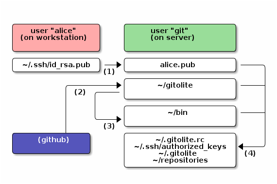

The files names you see there are **only for information**. You do **not** have to do anything to them yourself; in fact you should not! You only need the command for each step shown:

1. Copy the admin's pubkey to the server as "alice.pub".
2. Run `git clone git://github.com/sitaramc/gitolite` or equivalent.
3. Run `gitolite/install -ln`.
4. Run `gitolite setup -pk alice.pub`.

Note also that you only need ONE real user on the server. In our example it is git. In particular, you do NOT create Unix userids for your gitolite users.

#### 2.1.2.2 prepare for the install

The simplest, most foolproof, way of ensuring that your gitolite install + setup will succeed is to use a brand new userid as the hosting user. If that is not possible, make sure the following do NOT exist in that user's home directory: `~/.gitolite.rc`, `~/.gitolite`, `~/repositories`, and `~/.ssh/authorized_keys`.

Before you go trashing that authorized keys file, please make sure you know the password to the 'git' user, or know the root password on the machine!

The authorized keys file *can* exist, actually, as long as none of the keys you intend to use with gitolite are present in it. But again, if you're not an ssh guru, you should probably play safe.

#### 2.1.2.3 get the software

Get the software using git-clone:

```
git clone git://github.com/sitaramc/gitolite
```

You can use this as is, or you can check out the latest tag to make sure you're running a tagged version instead of just the current 'master'.

#### 2.1.2.4 install

Gitolite has one server side command: `gitolite`. You don't need to place it anywhere special; in the worst case you can run it with the full path.

"Installation" consists deciding where to put it:

1. Keep the sources anywhere and use the full path to run the `gitolite` command.
2. Keep the sources anywhere and symlink *just* the `gitolite` program to some directory on your `$PATH`.
3. Copy the sources somewhere and use that path to run the `gitolite` command.

Option 2 is the best for general use, but here's the scoop on all of them:

```
# option 1
gitolite/install

# option 2
gitolite/install -ln
# defaults to $HOME/bin (which is assumed to exist)
#   ** or **
# or use a specific directory (please supply FULL path):
gitolite/install -ln /usr/local/bin

# option 3
# (again, please supply a FULL path)
gitolite/install -to /usr/local/gitolite/bin
```

Creating a symlink doesn't need a separate program but 'install' also runs `git describe` to create a VERSION file, which can be very important if you want support :-)

#### 2.1.2.5 setup

For the first-time setup, you need to have a public key file (usually from the admin's workstation) ready. If the main gitolite admin's username is "alice", this file should be named "alice.pub" and copied to the server.

Once that is done, run:

```
gitolite setup -pk alice.pub
```

If that completes without any warnings, you are done. If it had a warning, you probably supplied a key which already has shell access to the server. That won't work; you'll have to generate and use a different key pair for gitolite access and use host aliases to distinguish between the two. While you're there, read both the ssh pages. Twice.

The 'setup' command has other uses, so you will be running it at other times after the install as well:

- To setup the update hook when you move existing repos to gitolite. This also applies if someone has been fiddling with the hooks on some repos and you want to put them all right quickly.
- To replace a lost admin key.
- To setup gitolite for http mode (run 'gitolite setup -h' for more info).

When in doubt, run 'gitolite setup' anyway; it doesn't do any harm, though it may take a minute or so if you have more than a few thousand repos!

### 2.1.3 upgrading

- Update your clone of the gitolite source.
- Repeat the install command you used earlier (make sure you use the same arguments as before).
- Run `gitolite setup`.

After you upgrade gitolite, you may also want to upgrade your rc file (`~/.gitolite.rc`). See the rc file documentation for that.

### 2.1.4 appendix 1: moving servers

Note: This section has one or more forward references.

Nothing in any of the gitolite install/setup/etc will ever touch the *data* in any repository except the gitolite-admin repo. The only thing it will normally touch is the `update` hook. So one fool-proof way of "moving" servers is this:

1. Clone the latest gitolite-admin repo from the old server to your workstation. Make sure you have an admin key that has RW+ rights to the gitolite-admin repo; you will need this later.
2. Install gitolite on the new server, using the same key for the admin as for the old server.
3. Copy the rc file from the old server, overwriting this one.
4. Disable the old server so people won't push to it.
5. Copy all the repos over from the old server. Make sure the files end up with the right ownership and permissions; if not, chown/chmod them.

   The gitolite-admin repo already exists on the new server (it's just a bare bones conf file). Do NOT overwrite it. (Not because it contains anything useful, but because the next step will then fail!)
6. Go to the clone you made in step 1, add a new remote (or change an existing one) to point to the new server, then `git push -f` to it.
7. Run `gitolite setup`.

## 2.2 Basic Administration

If you really, really, really want to manage gitolite directly on the server, i.e., without cloning the gitolite-admin repo, you can -- here's how. This is likely to be of interest mainly to puppet/chef type installations.

Day-to-day management of a gitolite site is done by cloning the special 'gitolite-admin' repo, making appropriate changes to it, and pushing it back to the server. The concepts and terminology page has a section with some details on what happens after the push.

In other words, do **NOT** add new repos or users manually on the server!

### 2.2.1 clone the gitolite-admin repo

To clone the admin repo, go to the workstation where the public key used in 'setup' came from, and run this:

```
git clone git@host:gitolite-admin
```

NOTE that (1) you must not include the `repositories/` part (gitolite handles that internally), and (2) you may include the ".git" at the end but it is optional.

If this step fails, be sure to look at the two pages linked from the ssh page before asking for help. (A very basic first step is to run `ssh git@host info`; this page tells you what to expect).

### 2.2.2 add/remove users

NOTE: This section only applies to ssh mode. If you've installed gitolite in http mode, adding and removing users is outside the scope of gitolite.

Strictly speaking, gitolite doesn't know where users come from. (If that surprises you, go back to the concepts page and read the section on "authentication and authorisation"). However, gitolite does help with ssh-based authentication, by making it easy to add and remove users from `~/.ssh/authorized_keys`.

To add or remove users, you have to clone the gitolite-admin repository, then add or remove ssh pubkey files from the "keydir/" directory in the clone. Then commit those changes and push.

Here's how to add users to gitolite. "alice" is the administrator and is adding "bob" and "carol".

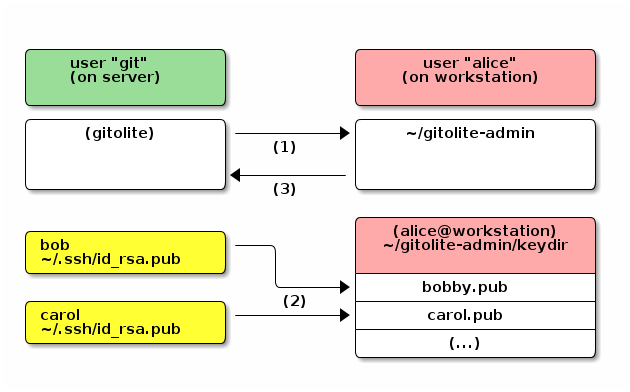

All this is done from the admin (Alice)'s workstation. The steps are:

1. Run `git clone git@server:gitolite-admin`.
2. Obtain pubkeys from each user; email, USB, DHL, pigeon post, owl mail, any method you like.

   Rename each received file to the name of the user, add a ".pub" at the end, copy it into `keydir/` in the gitolite-admin repo you cloned.
3. Run `git add keydir`, then `git commit`, then `git push`.

You do NOT need to add Carol or Bob as *real* (Unix) users. You do NOT add their keys directly anywhere on the server, and you most definitely do NOT fiddle with the authorized_keys file on the server directly!

To **remove** a user, `git rm keydir/alice.pub`.

Commit and push the changes. On receiving the push, gitolite will carry out the changes specified.

**NOTE**: your users' public key is typically `$HOME/.ssh/id_rsa.pub` on her workstation. Please make sure it is in openssh's default format.

#### 2.2.2.1 multiple keys per user

You can put pubkeys in subdirectories within "keydir/", because the user name is simply the *base name* of the public key file name. That is, 'keydir/alice.pub', 'keydir/home/alice.pub', 'keydir/laptop/alice.pub', (or even 'keydir/work/desktop/alice.pub' -- any number of subdirectory levels are OK) all resolve to user "alice".

This is the simplest and most understandable way to allow multiple keys per user.

#### 2.2.2.2 old style multi-keys

There is another way that involves creating key files like `alice@home.pub` and `alice@laptop.pub`, but there is a complication because gitolite also allows *full email addresses* as user names. (I.e., `sitaramc@gmail.com.pub` denotes the user called `sitaramc@gmail.com`).

This older method of enabling multi-keys was developed to deal with that. It will continue to work and be supported in *code*, simply because I prefer it. But I will not accept questions or doc patches for it, because it seems it is too difficult to understand for a lot of people. This table of sample pubkey filenames and the corresponding derived usernames is all you get:

- plain username, no multikey

  ```
  sitaramc.pub                            sitaramc
  ```

- plain username, with multikeys

  ```
  sitaramc@laptop.pub                     sitaramc
  sitaramc@desktop.pub                    sitaramc
  ```

- email address as username, no multikey

  ```
  sitaramc@gmail.com.pub                  sitaramc@gmail.com
  ```

- email address as username, with multikeys

  ```
  sitaramc@gmail.com@laptop.pub           sitaramc@gmail.com
  sitaramc@gmail.com@desktop.pub          sitaramc@gmail.com
  ```

### 2.2.3 add, remove, and rename repos

**NOTE**: this page describes how to add **new** repos. To bring already existing repos under gitolite's control, click here.

To **add** a new repo, you have to clone the gitolite-admin repository, then edit the `conf/gitolite.conf` file. In that file, add the repo, along with at least one user with some permissions.

You can add the new repo in its own paragraph:

```
repo bar
    RW+     =   alice
```

You can also add it to an existing repo line, if the new repo is intended to have the same access rules.

```
repo foo bar
    RW+     =   alice
```

Commit and push the changes. Gitolite will create a bare, empty, repo on the server that is ready to be cloned and pushed to.

As you can see, the "repo" line can have any number of repo names or repo group names in it. However, it can only be one line; this will not work

```
repo foo
repo bar    # WRONG; 'foo' is now forgotten
    RW+     =   alice
```

If you have too many to fit on one line comfortably, you can create and use a repo group:

```
@myrepos    =   foo
@myrepos    =   bar
    .
    .
    .
@myrepos    =   zzq

repo @myrepos
    RW+     =   alice
```

#### 2.2.3.1 removing/renaming a repo

Removing a repo is not so straightforward. You certainly must remove the appropriate lines from the `conf/gitolite.conf` file, but gitolite will not automatically delete the repo from the server. You have to log on to the server and do the dirty deed yourself :-)

It is best to make the change in the conf file, push it, and *then* go to the server and do what you need to.

Renaming a repo is also not automatic. Here's what you do (and the order is important):

- Go to the server and rename the repo at the Unix command line. Don't forget to retain the ".git" extension on the directory name.
- Change the name in the conf/gitolite.conf file in your gitolite-admin repo clone, and add/commit/push.

### 2.2.4 appendix 1: bringing existing repos into gitolite

**WARNINGS**

- Gitolite **will clobber** any existing `update` hook in your repos when you do this. Please see either the cookbook or the non-core page for information on how to make your existing update hook work with gitolite.
- Gitolite *may clobber* any existing "git-daemon-export-ok" file in your repo; see the page on allowing access to gitweb and git-daemon for how to enable that via gitolite.

With that out of the way, here's how to do this:

First, on the server:

- Move the repos to `$HOME/repositories`.
- Make sure that:
  - They are all *bare* repos.
  - All the repo names end in ".git".
  - All the files and directories are owned and writable by the gitolite hosting user (especially true if you copied them as root).
  - There are no symbolic links left over from wherever the files were brought from.
- Run `gitolite setup`. **If you forget this step, you can also forget about write access control!**

Then, back on your workstation:

- If the repos are normal repos, add them to conf/gitolite.conf in your clone of the admin repo, then commit and push the change.

  If the repos are wildcard repos that already match some repo regex in the conf file, you need to manually create the gl-creator file, like so:

  ```
  echo username > ~/repositories/path/to/repo.git/gl-creator
  ```

  I haven't yet found this to be common enough to bother wrapping it in a nice interface or command.

## 2.3 The "conf" file (`conf/gitolite.conf`)

You might recall from the basic administration page that this file is part of the gitolite-admin repo. You need to clone that repo, make and commit changes to this file, and push the commits back.

The `conf/gitolite.conf` file (often called just "the conf file" for short) is one of the two most important files in gitolite. It specifies repo names and access rules, as well as repo options of various kinds and git-config values.

Pretty much all day-to-day management, except managing users, happens from this file.

We'll use the following example to describe it's features. (A tip of the hat to Teemu Matilainen's gitolite vim-syntax file for the colors.)

```
# sample conf/gitolite.conf file

@staff              =   dilbert alice           # groups
@projects           =   foo bar

repo @projects baz                              # repos
    RW+             =   @staff                  # rules
    -       master  =   ashok
    RW              =   ashok
    R               =   wally

    option deny-rules           =   1           # options
    config hooks.emailprefix    = '[%GL_REPO] ' # git-config
```

### 2.3.1 basic syntax

As the example above shows, the syntax is fairly straightforward and simple.

- In general, everything is **space separated**; there are no commas, semicolons, etc., in the syntax.
- **Comments** are in the usual shell-ish style.
- **User names** and **repo names** are as simple as possible; they must start with an alphanumeric, but after that they can also contain `.`, `_`, or `-`. Usernames can optionally be followed by an `@` and a domainname containing at least one `.` (this allows you to use an email address as someone's username).
- **Group names** are like simple usernames (i.e., not email addresses) but start with an `@` sign.
- Reponames can contain `/` characters (this allows you to put your repos in a tree-structure for convenience).
- There are no continuation lines by default. You do not need them; the section on groups will tell you how you can break up large lists of names in a group definition into multiple lines. (But if you *must* have them, you can optionally enable them; look for "continuation-lines" in `~/.gitolite.rc`).

### 2.3.2 include files

Gitolite allows you to break up the configuration into multiple files and include them in the main file for convenience. For example:

```
include     "foo.conf"
```

will include the contents of the file "conf/foo.conf".

- You can also use a glob (`include "*.conf"`), or put your include files into subdirectories of "conf" (`include "foo/bar.conf"`), or both (`include "repos/*.conf"`).
- Included files are always searched from the gitolite-admin repo's "conf/" directory, unless you supplied an absolute path. (Note: in the interests of cloning the admin-repo sanely you should avoid absolute paths!)
- If you ended up recursing, files that have been already processed once are skipped, with a warning.
- It is not a fatal error for an include file to be missing. If it is a glob, you won't even get a warning.

Advanced users: `subconf`, a command that is very closely related to `include`, is documented here.

**Please note** that whenever you see "the `conf/gitolite.conf` file" or "the conf file" in gitolite documentation, it means the combined text after the include processing is done.

### 2.3.3 group definitions

You can group repos or users for convenience. The syntax is the same for both and does not distinguish; until you *use* the group name it could really be either.

Here's an example:

```
@developers     =   dilbert alice wally
```

Group definitions accumulate; this is the same as the above:

```
@developers     =   dilbert
@developers     =   alice
@developers     =   wally
```

You can use one group in another group definition; the values will be expanded immediately (meaning later additions will not appear in the second group).

```
@developers     =   dilbert alice
@interns        =   ashok
@staff          =   @interns @developers
@developers     =   wally

# wally is NOT part of @staff
```

Here's a very simple but complete example of using groups:

```
@developers     =   dilbert alice wally
@foss-repos     =   git gitolite

repo @foss-repos
    RW+         =   @developers
```

#### 2.3.3.1 special group `@all`

`@all` is a special group name that is often convenient to use if you really mean "all repos" or "all users".

#### 2.3.3.2 warnings on undefined groups

[output not shown]

Gitolite cannot truly catch undefined groups because the conf parser is 1-pass, and you're allowed to define a group *after* it is used, like so:

(v3.5.3+) However, in a simplistic attempt to help people tearing their hair out because of a typo, gitolite will warn if a group is not defined when it is used. So if you defined it later, either ignore the warning or move the definition up.

Note that these warnings do NOT appear if you're getting user group info from LDAP.

#### 2.3.3.3 getting user group info from LDAP

Gitolite's groups are pretty convenient, but some organisations already have similar (or sufficient) information in their LDAP store.

Gitolite can tap into that information, with a little help. Write a program which, given a username, queries your LDAP store and returns a space-separated list of groups that the user is a member of. Then put the full path to this program in an rc variable called `GROUPLIST_PGM`, like so:

```
GROUPLIST_PGM           =>  '/home/git/bin/ldap-query-groups',
```

Now you can use those groupnames in access rules in gitolite, because the user is a member of those groups as well as any normal gitolite groups you may have added him to in the conf file.

Caution: your program must do its own logging if you want the audit trail of "why/how did this user get access to this repo at this time?" to resolve properly. Gitolite does not do any logging of the results of the queries because for people who don't need it that would be a huge waste.

### 2.3.4 access rules

Some of the pictures are thanks (*enormous* thanks!) to someone who contributed them but does not want to be named (go figure!). She even converted them to ditaa format when I asked; these are not as pretty as what she sent me originally but they're vim-editable in source form :-)

This section talks about how gitolite's access rules work. It's a **very important** section, and well worth spending some time on.

Gitolite's access rules are designed to be easy to use for common situations, such as some of the examples you saw earlier. However, they also pack a lot of power and flexibility.

Access rules decide whether a particular access is allowed or denied. An access is defined by four pieces of data: "reponame, username, operation, and ref". Each rule also has four similar pieces of data, and of course there are several rules -- some people have thousands! -- in the conf file. This section will try and explain how these rules are used to decide if a given operation is to be allowed or denied.

#### 2.3.4.1 what does a rule look like?

[output not shown]

You've seen some simple rules so far, for example in the basic administration page. Here's a slightly more complex one, just for illustration.

A "repo" line names one or more repos, and is followed by one or more rule lines. All the rules from then till the next "repo" line apply to the repo(s) specified in the repo line -- in this example, the 'foo' and 'bar' repos.

Each rule line has a "permission" field, zero or more "refex"es, and one or more user or user group name after the equal sign.

The "repo" line can also have repo groups, as we have seen in the section on groups above. Also, it can have regular expressions that match multiple repos.

Before describing the various fields more formally, here's a description of what this specific rule list is saying:

- alice and the team leads can do whatever they want (i.e., push, rewind, or delete any branch or tag).
- dilbert and the dev team has these restrictions
  1. they can do anything to branches whose names start with "dev/"
  2. they can create or fast-forward push, but not rewind or delete, any branch except master
  3. they can create (but not update/delete) any tag except tags starting with "v" followed by a digit.
- managers can read the repo but they can't push anything.

More formally, a rule line has the following fields:

##### 2.3.4.1.1 the permission field

The permission field gives the type of access this rule line permits. The most commonly used permissions are:

- R, to allow read operations only
- RW, to allow fast-forward push of a branch, or create new branch/tag
- RW+, to allow pretty much anything -- fast-forward, rewind or delete branches or tags
- `-` (the minus sign), to **deny** access.

There are also other, less commonly used, types of permissions.

##### 2.3.4.1.2 the "refex" field

You cannot write rules for all possible branch and tag names (i.e., refs) that users will push. The only sensible way to do this is to use regular expressions instead.

A refex is a word I made up to mean "a regex that matches a ref".

In addition:

- If no refex is supplied, it defaults to `refs/.*`, for example in a rule like this:

  ```
  RW              =   alice
  ```

- A refex not starting with `refs/` (or `VREF/`) is assumed to start with `refs/heads/`. This means normal branches can be conveniently written like this:

  ```
  RW  master      =   alice
  # becomes 'refs/heads/master' internally
  ```

  while tags will need to be fully qualified

  ```
  RW  refs/tags/v[0-9]    =   bob
  ```

- A refex is implicitly anchored at the start, but not at the end. In regular expression lingo, a `^` is assumed at the start (but no `$` at the end is assumed). So a refex of `master` will match all these refs:

  ```
  refs/heads/master
  refs/heads/master1
  refs/heads/master2
  refs/heads/master/full
  ```

  More commonly, a refex of `refs/tags/v[0-9]` will match all versioned tags (i.e., not just `v1` but also `v12`, `v1.2`, `v12345`, etc.)

  If you want to restrict the match to just the one specific ref, add a $ at the end, for example:

  ```
  RW  master$     =   alice
  ```

You can also use virtual refs to perform extra checks and controls that you can't do with just the normal ref (like refs/heads/master) being pushed. The most common example is restricting pushes by dir/file name, but there are lots of other possibilities.

##### 2.3.4.1.3 user/user group list

Like the repos on the repo line, you can have any number of user names and/or user group names on the rule line. (However, please note that there is no concept of regular expressions for user names).

**SECTION SUMMARY**: at this point you know that each rule basically specifies a repo, user, permission, and a "refex".

#### 2.3.4.2 rule accumulation

*All* the rules for a repo need not be specified in one place. For example, you might see something like this, perhaps at the top or bottom of the conf file:

```
# managers should be able to read any repo
repo @all
    R   =   @managers
```

or perhaps this.

```
# anyone can clone open source repos
repo @FOSS
    R   =   @all
```

If a bunch of projects share some naming convention, you can specify any rules that are common to all of them by specifying the set of repos that are affected as a regular expression. Notice that the regex can be defined directly in the repo line, or it can be defined in a group and the *group* used in the repo line; it's all the same to gitolite.

```
repo FOSS/..*
    # ...rules for repos under FOSS/

@secret     =   secret/..* private/..*
repo @secret
    # ...rules for repos under secret/ and private/
```

Finally, although not very common, you can certainly do things like this. Note that the "other repos and rules" may indirectly include repo "foo" (for example it there were rules for "repo @all", or some other group that "foo" was a member of).

```
repo foo
    # ...some rules...

# ...other repos and rules...

repo foo
    # ...more rules for foo...
```

When access is being checked for an operation against a repo, **all the rules that pertain to that repo are collected, in the order they were seen in the conf file**.

Gitolite then **discards those rules that do *not* apply to the user whose access is being checked**. (A rule applies to a user if the user's name appears in the rule (after the equal sign), or if he is a member of any of the group names that appear in the rule.)

##### 2.3.4.2.1 defining "user" and "repo"

To be very specific, when we speak of "user" and "repo" in rules,

- "user" means "user or a group that he/she is a member of", and
- "repo" means "repo, or a group that it is a member of, or a regex that matches it, or a group that contains a regex that matches it".

### 2.3.5 access control rule matching

Access control rule matching is pretty simple. From the previous section, you know what "permission", "refex", "user", and "repo" are. Here's how the rules are used to decide whether to allow or deny a request.

Access is checked once only for "read" operations, but twice for "write"s.

(Note that the `deny-rules` option, mentioned below, is explained in more detail in a later section.)

**Check #1**: the first check happens as soon as gitolite-shell receives control (from sshd or httpd). gitolite-shell will pass control to git-upload-pack or git-receive-pack only if this check succeeds.

- collect all the rules pertaining to this repo *and* this user
- ignore all the refexes; they don't apply to the first access check
- **if** the `deny-rules` option is **not** in effect for this repo, discard all the `-` (deny) rules
- look at the rules *in sequence*:
  - if you find a `-`, access is denied
  - for a "read" operation (clone, fetch, ...), if you find a rule containing `R`, access is allowed
  - for a "write" operation (push), if you find a rule containing `W`, access is allowed
  - if there are no more rules left, access is denied

**Check #2**: the second check only happens for "push" operations. It is invoked by `git-receive-pack` running the gitolite-installed `update` hook. If access is denied, the update hook fails, and git then aborts the push for this ref. (See `man githooks` for more.)

In the following description, we use the word `operation` instead of `W`, because the actual operation could be a plain, fast-forward, push (`W`) or a rewind/delete (`+`). Other, less commonly used, values are "C", "D", or "M"; see here.

- collect all the rules pertaining to this repo *and* this user
- discard all the rules where the refex does not match the ref (branch or tag) being pushed
- look at the rules *in sequence*:
  - if you find a `-`, access is denied
  - if you find a rule containing the operation you are performing, access is allowed
  - if there are no more rules left, access is denied

#### 2.3.5.1 an example

Just to be clear, let's work out an example of what happens when dilbert tries to push a branch called "xyz".

We'll pretend the rule list looks like this.

```
# managers should be able to read any repo
repo @all
    R                       =   @managers

# ...other rules for other repos...

repo foo bar

    RW+                     =   alice @teamleads
    -   master              =   dilbert @devteam
    -   refs/tags/v[0-9]    =   dilbert @devteam
    RW+ dev/                =   dilbert @devteam
    RW                      =   dilbert @devteam
    R                       =   @managers
```

After adding a default refex and expanding the supplied ones (see the refex section earlier), this is what it looks like. We've added line numbers for convenience; we'll see why later.

```
 1 # managers should be able to read any repo
 2 repo @all
 3     R   refs/.*             =   @managers
 4
 5     # ...other rules for other repos...
 6
 7 repo foo bar
 8
 9     RW+ refs/.*             =   alice @teamleads
10     -   refs/heads/master   =   dilbert @devteam
11     -   refs/tags/v[0-9]    =   dilbert @devteam
12     RW+ refs/heads/dev/     =   dilbert @devteam
13     RW  refs/.*             =   dilbert @devteam
14     R   refs/.*             =   @managers
```

This represents a set of rules that are basically this:

```
repo    user        perm    ref                 (from line)

 foo     @managers  R        refs/.\*                3
 foo     alice      RW+      refs/.\*                9
 foo     @teamleads RW+      refs/.\*                9
 foo     dilbert    -        refs/heads/master       10
 foo     @devteam   -        refs/heads/master       10
 foo     dilbert    -        refs/tags/v[0-9]        11
 foo     @devteam   -        refs/tags/v[0-9]        11
 foo     dilbert    RW+      refs/heads/dev/         12
 foo     @devteam   RW+      refs/heads/dev/         12
 foo     dilbert    RW       refs/.\*                13
 foo     @devteam   RW       refs/.\*                13
 foo     @managers  R        refs/.\*                14
```

Which of these rules apply for dilbert? We'll assume he's not a team lead, as *that* would defeat the whole purpose of this example! We *know* he's not a manager, as that would defeat the whole purpose of the comic! Finally, we assume he's also not part of "@devteam", (otherwise why would you name him separately in all those lines?).

So we discard all those rules, which leaves us, for repo "foo" and user "dilbert":

```
perm    ref                 (from line)

-        refs/heads/master       10
-        refs/tags/v[0-9]        11
RW+      refs/heads/dev/         12
RW       refs/.\*                13
```

So what happens when dilbert tries to push a branch called "xyz"?

At check #1, the data gitolite has is that "oper" is "W" (and ref of course is unknown). We discard lines 10 and 11 (the `deny-rules` option is off by default, so we ignore `-` rules). Line 12 supplies a perm of "RW+", which contains "W" (the "oper") so access is allowed.

At check #2, the data gitolite has is that "oper" is "W" and ref is `refs/heads/xyz`. We discard the first three rules, since the ref does not match any of those refexes. That leaves just line 13.

If the push were a fast-forward push, the "oper" would be "W", and since it is contained in the perm for rule 13, access is allowed.

However, if he were to try a rewind-push, then the "oper" would be "+", which is not contained in "RW", it wouldn't match, then control would go back for the *next* rule, and since there aren't any more, access would be denied.

#### 2.3.5.2 tracing the access control decision

(v3.6.1) Gitolite can help you trace this logic quickly and easily. Here's one example run, with the above rules. This one tests whether dilbert can push to repo foo (check #1). Note that the syntax for specifying an unknown ref in this command is 'any'.

```
$ gitolite access -s foo dilbert W any
legend:
    d => skipped deny rule due to ref unknown or 'any',
    r => skipped due to refex not matching,
    p => skipped due to perm (W, +, etc) not matching,
    D => explicitly denied,
    A => explicitly allowed,
    F => denied due to fallthru (no rules matched)

  d        gitolite.conf:10         -   refs/heads/master   =   dilbert @devteam
  d        gitolite.conf:11         -   refs/tags/v[0-9]    =   dilbert @devteam
  A        gitolite.conf:12         RW+ refs/heads/dev/     =   dilbert @devteam

refs/heads/dev/
```

Now see what happens when we try check #2 (we've omitted the legend in the output, since it's always the same):

```
$ gitolite access -s foo dilbert W xyz

  r        gitolite.conf:10         -   refs/heads/master   =   dilbert @devteam
  r        gitolite.conf:11         -   refs/tags/v[0-9]    =   dilbert @devteam
  r        gitolite.conf:12         RW+ refs/heads/dev/     =   dilbert @devteam
  A        gitolite.conf:13         RW  refs/.*             =   dilbert @devteam

refs/.*
```

And if you try a force push:

```
$ gitolite access -s foo dilbert + refs/heads/xyz

  r        gitolite.conf:10         -   refs/heads/master   =   dilbert @devteam
  r        gitolite.conf:11         -   refs/tags/v[0-9]    =   dilbert @devteam
  r        gitolite.conf:12         RW+ refs/heads/dev/     =   dilbert @devteam
  p        gitolite.conf:13         RW  refs/.*             =   dilbert @devteam
  F           (fallthru)

+ refs/heads/xyz foo dilbert DENIED by fallthru
```

I hope that was useful! Be sure you correlated the output of 'gitolite access -s' with the rule workflow pictures and corresponding descriptions to cement your understanding.

#### 2.3.5.3 read access respecting deny rules

Note: This section has one or more forward references, referring to gitolite options, and the special users gitweb and daemon).

Normally, deny rules are ignored by access check #1 (the one that runs *before* git-upload-pack or git-receive-pack is called by gitolite-shell); they apply only to check #2 (the update hook check).

But sometimes you want this "pre-git" access check to respect deny rules; i.e., use the flow of check #2, not check #1. You tell gitolite to do this by setting the "deny-rules" option for the repo; when you do that, the flow of check #2 is used for both stages, before git *and* in the update hook.

#### 2.3.5.4 example 1

Here's an example. Here, we have lots of repos, which should all be accessible by gitweb or daemon, so we want the convenience provided by lines 6 and 7 (we don't want to put line 7 in *each* repo). However, we also have some secret repos (maybe the gitolite-admin repo and some others that we will list), which we want to prevent gitweb or daemon from seeing.

How do we do that?

```
 1 @secret = gitolite-admin secret-repo/..*
 2 repo @secret
 3     -   =   gitweb daemon
 4
 5
 6 repo @all
 7     R   =   gitweb daemon
 8
 9 # ...other repos and rules...
10
```

The naive approach -- putting in a deny rule just for those repos -- doesn't work. In fact nothing else seems to work either; you'll have to replace the `@all` with an exhaustive list of *all repos other than the secret repos*.

That's... painful!

```
 1 @secret = gitolite-admin secret-repo/..*
 2 repo @secret
 3     -   =   gitweb daemon
 4     option deny-rules = 1
 5
 6 repo @all
 7     R   =   gitweb daemon
 8
 9 # ...other repos and rules...
10
```

What you really want is for that repo to always use check #2, even when it doesn't actually have a ref to test for.

This is done by adding *one* line, line 4 in this example. This sets a gitolite "option" that says you want "deny rules" to be applicable even for read access.

Once you do that, all you need to do is to ensure that the first rule encountered by these two "users" for those repos is a deny rule, so that it can take effect first. In this example, the placement of lines 2, 3 vis-a-vis lines 6, 7 matters -- don't switch them!

#### 2.3.5.5 example 2

```
@open = git gitolite foss/..* [...]

repo @all
    -   =   gitweb daemon
    option deny-rules = 1

repo @open
    R   =   gitweb daemon
    option deny-rules = 0
```

In this example the "open" repos are fewer in number, so it is the opposite situation to the above in terms of our ability to enumerate all the repos.

To see why this works, you need to understand that for options and config lines, a later setting overrides earlier ones. So we set it to 1 for all repos, then selectively set it to 0 for some.

This means the "deny-rules" option applies to *all the repos except the "open" repos*, and so the first rule encountered by gitweb and daemon is a deny rule, so they are denied read access. The "open" repos, on the other hand, get the normal default behaviour, which is to ignore deny rules for read access, and thus they only see the "R" permission.

### 2.3.6 appendix 1: different types of write operations

Git supplies enough information to the update hook to be able to distinguish several types of writes.

The most common are:

- `RW` -- create a ref or fast-forward push a ref. No rewinds or deletes.
- `RW+` -- create, fast-forward push, rewind push, or delete a ref.

Sometimes you want to allow people to push, but not *create* a ref. Or rewind, but not *delete* a ref. The `C` and `D` qualifiers help here.

- If a rule specifies `RWC` or `RW+C`, then *rules that do NOT have the C qualifier will no longer permit **creating** a ref*.

  Please do not confuse this with the standalone `C` permission that allows someone to create a **repo**
- If a rule specifies `RWD` or `RW+D`, then *rules that do NOT have the D qualifier will no longer permit **deleting** a ref*.

Note: These two can be combined, so you can have `RWCD` and `RW+CD` as well.

One very rare need is to reject merge commits (a commit series that is not a straight line of commits). The `M` qualifier helps here:

- When a rule has `M` appended to the permissions, *rules that do NOT have it will reject a commit sequence that contains a merge commit* (i.e., they only accept a straight line series of commits).

#### 2.3.6.1 summary of permissions

The full set of permissions, in regex syntax, is `-|R|RW+?C?D?M?`. This expands to one of `-`, `R`, `RW`, `RW+`, `RWC`, `RW+C`, `RWD`, `RW+D`, `RWCD`, or `RW+CD`, all but the first two optionally followed by an `M`.

### 2.3.7 appendix 2: gitolite access check flow

Here's lots more detail on the access check process, with flow diagrams.

When do the access checks happen and what are the four pieces of data (repo, user, operation, ref) in each case?

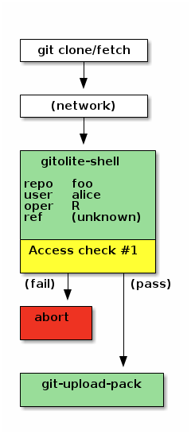

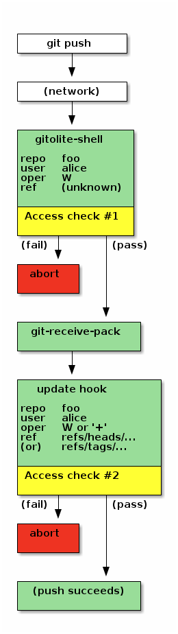

In these pictures the access checks are marked in yellow.

The picture on the left is for a read (git clone, fetch, ls-remote). There is only one access check for a read operation. If access is denied, the operation aborts. Otherwise, gitolite-shell invokes git-upload-pack.

Notice the information available to the access check. The "oper" (operation) is "R", indicating a read operation. The "ref" is listed as "unknown", although we could also call it "irrelevant"!

**Access check #1** proceeds with those 4 bits of information, and either passes or fails. If it passes, gitolite passes control to "git-upload-pack" and its job is done.

The flow for a push operation (the picture on the right) is *very* similar upto the first access check. The "oper" is "W" now, although the "ref" is still unknown. Even though this *is* a push, at this stage in the protocol nothing on the server knows what branch or tag or combination of them are coming down the wire, since we haven't executed git-receive-pack yet!

If it succeeds, gitolite passes control to "git-receive-pack", but its job is not done yet. *Git* will eventually invoke the update hook (see 'man githooks'). Gitolite has already grabbed this hook, which receives from git the ref name being pushed, as well as enough information to compute whether this push is a "fast-forward push" or a "rewind push". Based on this, gitolite sets the "oper" field to "W" or "+", respectively.

**Access check #2** proceeds with this information. The result is sent back to git-receive-pack (in the form of an exit code; again, see 'man githooks'), and the push fails or succeeds based on that.

#### 2.3.7.1 putting it all together

At this point, we have the following pieces of information:

- A set of rules, each containing 4 pieces of data: repo, user, perm, refex. They are in the sequence they were found in the conf file.

  We discard all rules that do not apply to this repo and this user, which means our set of rules have only two fields: perm, refex.

  As a quick reminder, perm is one of R, RW, RW+, or `-`.
- Four elements that make up the access being attempted: repo, user, oper, ref.

  Again, as a reminder, the "oper" is **one letter**. For "check #1" it is either R or W, and for check #2 it can be W or +.

Note on permissions and "oper": there are other types of permissions, but for our discussion these are enough. The others are rare, and anyway it is easy to extrapolate to them.

With that background, here's the flow. The one on the left is for check #1 (ref is unknown) while the one on the right is for check #2 (ref is known). **Note** that the yellow (decision) boxes are numbered to help later discussion.

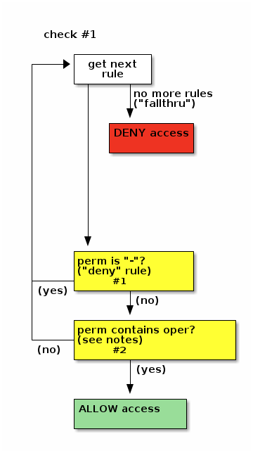

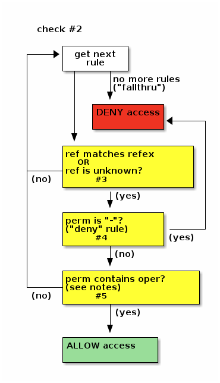

As you can see, deny rules are ignored by check #1 -- they're not tested in any way. For check #2, if there is a deny rule whose refex matched the ref, access is denied (as you'd expect).

## 2.4 the "rc" file (`$HOME/.gitolite.rc`)

**IMPORTANT**: if you have a v3.0-v3.3 rc file it is documented here, and it will still work. Please see appendix A below for details.

**If you're migrating from v2**, there are some settings that MUST be dealt with **before** running `gitolite setup`; please read the migration page and linked pages, and especially the one on "presetting the rc file".

Note: This page has several forward references!

The rc file is designed to be the only thing unique to your site for most setups.

The rc file is well commented. Please look at the `~/.gitolite.rc` file that gets installed when you setup gitolite. **You can always get a default copy for your current version by running `gitolite print-default-rc`.** (Please see appendix A for upgrade instructions.)

### 2.4.1 structure of the rc file

The rc file is perl code, but you do NOT need to know perl to edit it. Just mind the commas, use single quotes unless you know what you're doing, and make sure the brackets and braces stay matched up!

As you can see there are 3 types of variables in it:

- A lot of simple variables (like `UMASK`, `GIT_CONFIG_KEYS`, etc.).
- A hash or two (like `ROLES`).
- And one large list of features to be enabled (`ENABLE`).

This page documents only some of them; for most of them it's best to look in the actual rc file or in each of their individual documentation files around; start with "non-core" gitolite. If a setting is used by a command then running that command with '-h' may give you additional information.

### 2.4.2 specific variables

- `$UMASK`, octal, default `0077`

  The default UMASK that gitolite uses gives `rwx------` permissions to all the repos and their contents. People who want to run gitweb (or cgit, redmine, etc) realise that this will not do.

  The correct way to deal with this is to give this variable a value like `0027` (note the syntax: the leading 0 is required), and then make the user running the webserver (apache, www-data, whatever) a member of the 'git' group.

  If you've already installed gitolite then existing files will have to be fixed up manually (for a umask or 0027, that would be `chmod -R g+rX`). This is because umask only affects permissions on newly created files, not existing ones.
- `$GIT_CONFIG_KEYS`, string, default empty

  See the security note at the end of this page for why we do this.

  This setting allows the repo admin to define acceptable gitconfig keys.

  Gitolite allows you to set git config values using the "config" keyword; see here for details and syntax.

  You have 3 choices. By default `$GIT_CONFIG_KEYS` is left empty, which completely disables this feature (meaning you cannot set git configs via the repo config).

  The second choice is to give it a space separated list of settings you consider safe. (These are actually treated as a set of regular expressions, and any one of them must match).

  For example:

  ```
  $GIT_CONFIG_KEYS = 'core\.logAllRefUpdates core\..*compression';
  ```

  Each regex should match the *whole* key (in other words, there is an implicit `^` at the start of each regex, and a `$` at the end).

  The third choice (which you may have guessed already if you're familiar with regular expressions) is to allow anything and everything: `$GIT_CONFIG_KEYS = '.*';`
- `ROLES`, hash, default keys 'READERS' and 'WRITERS'

  This specifies the role names allowed to be used by users running the perms command. The wild repos doc has more info on roles.
- `OWNER_ROLENAME`, string, default undef

  (requires v3.5 or later)

  By default, permissions on a wild repo can only be set by the *creator* of the repo (using the perms command). But some sites want to allow other people to do this as well.

  To enable this behaviour, the server admin must first set this variable to some string, say 'OWNERS'. (He must also add 'OWNERS' to the ROLES hash described in the previous bullet).

  The creator of the repo can then add other users to the OWNERS role using the perms command.

  The perms command, the new "owns" command, and possibly other commands in future, will then give these users the same privileges that they give to the creator of the repo.

  (Also see the full documentation on roles).
- `LOCAL_CODE`, string

  This is described in more detail here. Please be aware **this must be a FULL path**, not a relative path.

### 2.4.3 security note: gitolite admin and shell access

People sometimes ask why this file is also not revision controlled. Here's why.

Gitolite maintains a clear distinction between

- people who can push to the gitolite-admin repo, and
- people who can get a shell or run arbitrary commands on the server.

This may not matter to many (small) sites, but in large installations, the former is often a much larger set of people that you really don't want to give shell access to.

Therefore, gitolite tries very hard to make sure that people in the first set are not allowed to do anything that gets them into the second set.

### 2.4.4 appendix A: upgrading the rc file

First, note that upgrading the rc file is always *optional*. However, it may help if you want to use any of the new features available in later gitolite releases, in the sense that the lines you need to add may already be present (commented out) in the rc file, so you just need to uncomment them instead of typing them in yourself.

If you have a v3.0-v3.3 rc file it is documented here, and it will still work. In fact internally the v3.4 rc file data gets converted to the v3.3 format. There's a simple program to help you upgrade a v3.3 (or prior) rc file (in v3.6.1+, see contrib/utils/rc-format-v3.4), but it has probably not seen too much testing; please tread carefully and report any problems you find.

Upgrading from any v3.4+ rc file to any later gitolite is fairly easy, though still manual. One useful aid is that, as of v3.6.4, you can run `gitolite query-rc -d` to dump the entire rc structure to STDOUT. **This only requires that gitolite be v3.6.4+; your rc file can still be the old one.** You can use this to confirm you did not miss something during the manual rc upgrade.

- dump the current rc by running `gitolite query-rc -d > old.dump` (assuming you upgraded to v3.6.4 or higher)
- save your old rc file: `mv ~/.gitolite.rc ~/old.gitolite.rc`
- get a "default" rc for your current gitolite by running

  ```
  gitolite print-default-rc > ~/.gitolite.rc
  ```

- use your favourite diff-ing editor on the old and the new files and figure out what to carry over from the old rc file to the new one.

  ```
  vimdiff ~/old.gitolite.rc ~/.gitolite.rc
  # or maybe kdiff3 or whatever
  ```

  This is the tricky part of course! Watch out for configs that got *moved* around, or in some cases removed completely, not just new config items.
- dump the new rc by running `gitolite query-rc -d > new.dump`
- compare the 2 rc dumps to make sure you've got everything covered.

## 2.5 the users' view

Note: This page has several forward references. However, I didn't want to place it too far down the list, yet at the same time it's too small to split it into two pages.

This page talks about what gitolite looks like to non-admins, and the commands and features available to them.

### 2.5.1 accessing gitolite

The most common setup is based on ssh, where your admin asks you to send him your public key, and uses that to setup your access.

Your actual access is either a git command (like `git clone git@server:reponame`, or an ssh command (like `ssh git@server info`).

Note that you do *not* get a shell on the server -- the whole point of gitolite is to prevent that!

**Note to people who think gitolite requires or can only handle a specific syntax for the URL**: Gitolite is designed in such a way that, unless there is an access violation, the *client* need not even *know* that something called gitolite is sitting between it and git on the server. In particular, this means *any* URL syntax listed in 'man git-clone' for ssh and/or http will work. The only things to note are:

- In ssh mode, you *must* use key-based authentication (i.e., passwords won't work; see the two pages linked from the ssh page for why).
- The path of the repo is what you put into the conf file (e.g., "testing", and not "repositories/testing" or "/home/git/repositories/testing" or such). A good rule of thumb is to use the exact name the `info` command (see below) shows you.
- The ".git" at the end is optional for **git** commands (i.e., you can use "testing.git" instead of "testing" for clone, fetch, push, etc., if you like) but **gitolite** commands in general (see below) will not like the additional ".git" at the end.

### 2.5.2 the info command

The only command that is *always* available to every user is the `info` command (run `ssh git@host info -h` for help), which tells you what version of gitolite and git are on the server, and what repositories you have access to. The list of repos is very useful if you have doubts about the spelling of some new repo that you know was setup.

### 2.5.3 normal and wild repos

Gitolite has two kinds of repos. Normal repos are specified by their full names in the config file. "Wildcard" repos are specified by a regex in the config file. Try the `info` command and see if it shows any lines that look like regex patterns, (with a "C" permission).

If you see any, it means you are allowed to create brand new repos whose names fit that regex. Normally, you create such repos simply by cloning them or pushing to them -- gitolite automatically creates the repo on the server side. (If your site is different, your admin will tell you).

When you create such a repo, your "ownership" of it (as far as gitolite is concerned) is automatically recorded by gitolite.

### 2.5.4 other commands

#### 2.5.4.1 set/get additional permissions for repos you created

The gitolite config may have several permissions lines for your repo, like so:

```
repo pub/CREATOR/..*
    C       =   ...some list of users allowed to create repos...
    RW+     =   CREATOR
    RW      =   user1 user2
    R       =   user3
```

If that's all it had, you really can't do much. Any changes to access must be done by the administrator. (Note that "CREATOR" is a reserved word that gets expanded to your userid in some way, so the admin can literally add just the first three lines, and *every* user listed in the second line (or *every authenticated user*, if you specified `@all` there) has his own personal repo namespace, starting with `pub/<username>/`).

To give some flexibility to users, the admin could add rules like this:

```
RW      =   WRITERS
R       =   READERS
```

(he could also add other roles but then he needs to read the documentation).

Once he does this, you can then use the `perms` command (run `ssh git@host perms -h` for help) to set permissions for other users by specifying which users are in the list of "READERS", and which in "WRITERS".

If you think of READERS and WRITERS as "roles", it will help. You can't change what access a role has, but you *can* say which users have that role.

**Note**: there isn't a way for you to see the actual rule list unless you're given read access to the special 'gitolite-admin' repo. Sorry. The idea is that your admin will tell you what "roles" he added into rules for your repos, and what permissions those roles have.

#### 2.5.4.2 adding a description to repos you created

The `desc` command is extremely simple. Run `ssh git@host desc -h` for help.

### 2.5.5 "site-local" commands

The main purpose of gitolite is to prevent you from getting a shell. But there are commands that you often need to run on the server (i.e., cannot be done by pushing something to a repo).

To enable this, gitolite allows the admin to setup scripts in a special directory that users can then run. Gitolite comes with a set of working scripts that your admin may install, or may use as a starting point for his own, if he chooses.

Think of these commands as equivalent to those in `COMMAND_DIR` in `man git-shell`.

You can get a list of available commands by running `ssh git@host help`.

### 2.5.6 "personal" branches

"personal" branches are great for environments where developers need to share work but can't directly pull from each other (usually due to either a networking or authentication related reason, both common in corporate setups).

Personal branches exist **in a namespace** of their own. The syntax is

```
    RW+ personal/USER/  =   @userlist
```

where the "personal" can be anything you like (but cannot be empty), and the "/USER/" part is **necessary (including both slashes)**.

A user "alice" (if she's in the userlist) can then push any branches inside `personal/alice/`. Which means she can push `personal/alice/foo` and `personal/alice/bar`, but NOT `personal/alice`.

(Background: at runtime the "USER" component will be replaced by the name of the invoking user. Access is determined by the right hand side, as usual).

Compared to using arbitrary branch names on the same server, this:

- Reduces namespace pollution by corralling all these ad hoc branches into the "personal/" namespace.
- Reduces branch name collision by giving each developer her own sub-hierarchy within that.
- Removes the need to think about access control, because a user can push only to his own sub-hierarchy.

## 2.6 help for emergencies

> **"Don't Panic!"**

### 2.6.1 install/setup issues

Most install/setup issues in ssh mode are caused by lack of ssh knowledge. Ssh is a complex beast, and can cause problems for people who are not familiar with its quirks.

**Be prepared to spend some time reading the ssh documentation that comes with gitolite**.

### 2.6.2 lost admin key/access

If you lost your gitolite **admin** key or access, here's what you do. We'll assume your username is "alice" (i.e., alice has RW or RW+ permissions on the gitolite-admin repo).

- Make yourself a new keypair and copy the public key to the server as 'alice.pub'.
- Log on to the server, and run `gitolite setup -pk alice.pub`.

That's it; the new alice.pub file replaces whatever existed in the repo before.

### 2.6.3 bypassing gitolite

You may have lost access because of a conf file error, in which case the above trick (which merely changes a pubkey) won't help. What you want is to make changes to the gitolite-admin repo (or perhaps just rewind) and push that. Here's how to do that:

- Log on to the server.
- Clone the admin repo using the full path: `git clone $HOME/repositories/gitolite-admin.git temp`.
- Make whatever changes you want -- add/replace a key, 'git revert' or 'git reset --hard' to an older commit, etc. Anything you need to fix the problem, really.
- Run `gitolite push` (or possibly `gitolite push -f`). **Note that's 'gitolite push', not 'git push'**.

**NOTE**: gitolite does **no access checking** when you do this!

### 2.6.4 botched something?

#### 2.6.4.1 fixing botched repos

If you copied some repos from somewhere else, or mucked with the hooks for some reason, or deleted any gitolite-specific files, or tried any other "behind the scenes" stunts, the quickest, sanest, way to fix everything up is:

- Make sure any new repos you copied in are mentioned in the gitolite.conf in some 'repo' line and the change pushed.
- Then run `gitolite setup` on the server.

If the repo you botched is a wild repo, there's a bit more to be done. Wild repos store the creator name in a file called gl-creator, and the data managed by the perms command in a file called "gl-perms". If these files got deleted, you may have to manually recreate them. The format is very simple and guessable by looking at those files on any other wild repo.

#### 2.6.4.2 cleaning out a botched install

Here's a list of files and directories to deal with:

- **Gitolite sources** -- can be found by running `which gitolite`. If it's a symlink, go to its target directory.
- **Gitolite admin directory** -- `$HOME/.gitolite`. Save the 'logs' directory if you want to preserve them for any reason.
- **The rc file** -- `$HOME/.gitolite.rc`. If you made any changes to it you can save it as some other name instead of deleting it.
- **The gitolite-admin repo** -- `$HOME/repositories/gitolite-admin.git`. You can clone it somewhere to save it before blowing it away if you wish.
- **Git repositories** -- `$HOME/repositories`. The install process will not touch any existing repos except 'gitolite-admin.git', so you do not have to blow away (or move) your work repos to fix a botched install.

  Only when you update the conf to include those repos and push the changes will those repos be touched. And even then all that happens is that the update hook, if any, is replaced with gitolite's own hook.
- **Ssh stuff** -- exercise caution when doing this, but in general it should be safe to delete all lines between the "gitolite start" and "gitolite end" markers in `$HOME/.ssh/authorized_keys`.

  Gitolite does not touch any other files in the ssh directory.

### 2.6.5 common errors

- `WARNING: keydir/<yourname>.pub duplicates a non-gitolite key, sshd will ignore it`

  You used a key that is already set to give you shell access. You cannot use the same key to get shell access as well as access gitolite repos.

  Solution: use a different keypair for gitolite. There's a wee bit more on this in the setup section of the install page. Also see why bypassing causes a problem and both the pages linked from ssh for background.
- `Empty compile time value given to use lib at hooks/update line 6`

  (followed by `Can't locate Gitolite/Hooks/Update.pm in @INC` a couple of lines later).

  You're bypassing gitolite. You cloned the repo using the full path (i.e., including the `repositories/` prefix), either directly on the server, or via ssh but with a key that gives you **shell** access.

  Solution: same as for the previous bullet.

  NOTE: If you really *must* do it, and this is a one-time thing, you can try `gitolite push` instead of `git push`. **BUT**... this defeats all gitolite access control, so if you're going to do this often, maybe you don't need gitolite!

### 2.6.6 uncommon errors

(This page intentionally left blank)

### 2.6.7 non-standard configs that'll trip you up

- **IMPORTANT**: although a default openssh config will not do this (AFAIK), **do not** allow the user to set environment variables if you care about security at all.
- If your 'git' binary is in a non-PATH location, or you have more than one version and want a specific one to be picked up, you will have to add a line like this at the end of the rc file (outside the `%RC` hash, but before the `1;` line):

  ```
  $ENV{PATH} = "/your/git/path:$ENV{PATH}";
  ```

- If you have your sshd configured to put the authorized_keys file somewhere other than the default (which is in .ssh in the hosting user's home directory), you'll probably have to roll your own ssh handling, either disabling 'ssh-authkeys' in the rc file, or building on that somehow (maybe a post-processing step that copies the relevant auth keys lines from the default file to the other).
- If you have sshd setup to not allow incoming ssh for the hosting user, gitolite won't work. Check things like 'Allowusers' setting in /etc/ssh/sshd_config etc. to make sure.
- If you have the home directory in a partition that is mounted noexec, gitolite won't work. I believe it would be sufficient if the ".gitolite" directory were moved to a different mount and symlinked, but please test thoroughly. A failure to execute a hook does not throw up any errors or warnings for you to notice!
- If the default shell is something like /bin/false, and/or not listed in /etc/shells, there might be problems.

### 2.6.8 things that are not gitolite problems

There are several things that appear to be gitolite problems but are not. I cannot help with most of these (although the good folks on irc or the mailing list -- see contact -- might be able to; they certainly appear to have a lot more patience than I do, bless 'em!)

- **Client side software**
  - putty/plink
  - jgit/Eclipse
  - Mac OS client **or** server
  - putty/plink
  - windows as a server
  - ...probably some more I forgot; will update this list as I remember...
  - did I mention putty/plink?
- **Ssh**

  The *superstar* of the "not a gitolite problem" category is actually ssh.

  Surprised? It is so common that it has its own page to tell you why it is *not* a gitolite problem, while another one tries to help you anyway!

  Everything I know is in that latter link. Please email me about ssh ONLY if you find something wrong or missing in those pages.
- **Git**

  I wish I had a dollar for each time someone did a *first push* on a new repo, got an error because there were "no refs in common (etc.)", and asked me why gitolite was not allowing the push.

  Gitolite is designed to look like just another bare repo server to a client (except requiring public keys -- no passwords allowed). It is *completely transparent* when there is no authorisation failure (i.e., when the access is allowed, the remote client has no way of knowing gitolite was even installed!)

  Even "on disk", apart from reserving the `update` hook for itself, gitolite does nothing to your bare repos unless you tell it to (for example, adding 'gitweb.owner' and such to the config file).

  BEFORE you think gitolite is the problem, try the same thing with a normal bare repo. In most cases you can play with it just by doing something like this:

  ```
  mkdir /tmp/throwaway
  cd    /tmp/throwaway
  git clone --mirror <some repo you have a URL for> bare.git
  git clone bare.git worktree
  cd worktree
  <...try stuff>
  ```

## 2.7 idiot-proof setup for gitolite

If I gave you this link to read, it most likely means either:

- (most common reason) You got really confused by ssh.
- (a bit less common) You got confused by how to administer users and repos using gitolite.

Don't take the title personally. The "idiot" in the title is indeed a real person who once bugged me so much I wrote this for him. However, I have since realised that this is also useful for (a) people for whom English is not the first language and (b) people who really should not be doing technical work at this level, but are forced to do it by circumstances.

### 2.7.1 pre-requisites, etc

These are the pre-requisites:

- Any Linux machine on which git has already been installed.
- Probably any BSD or legacy system like Solaris will also work, but I have not tested them.
  - I do not consider Apple devices to be Unix enough; it should work, but please do not ask me for help if it does not.

This page has several restrictions and constraints that seem unnecessary to people who **do** understand ssh. That's the whole point -- I'm compensating for lack of ssh knowledge by removing things that trip people up.

If even this page does not help you install gitolite, I probably cannot help you. Either you did not follow the instructions carefully (maybe some task has to be run on your workstation, but you ran it on the server, or you ran something as root when it should be as the hosting user, etc.), or your environment is far too different from standard Unix, or you have some other problem. In any case, it is not something I can help with. Sorry.

### 2.7.2 assumptions

- Your name is Ron. Substitute accordingly in the instructions below.
- You have a workstation.
- You have a server called `server`.
- You have root access on this server.

### 2.7.3 installation tasks

1. Create a new userid on the server, say `git`. This will be the **hosting user**. ("hosting user" means when you're done installing, your users will use URLs like `git@server:reponame` or `ssh://git@server/reponame`).

   **Make sure this is a NEW userid**.

   If the name you want already exists, then:
   - Log in as root.
   - If you have any data on that user's HOME directory save it somewhere else.
   - Delete the userid.
   - Completely wipe out (erase) the home directory of the user (since on most systems merely deleting the user does not remove the home directory).
   - Re-create the userid again.
2. If you don't already have one, make yourself an ssh keypair **on your workstation**.

   Do NOT add this public key to the authorised keys file on the newly created hosting user!

   Your ONLY access to the new (`git`) userid should be by logging onto the server as root, then running `su - git`.
3. Now copy the pubkey from your workstation (`~/.ssh/id_rsa.pub`) to the server as `/tmp/ron.pub`. (Your name is Ron, remember?)
4. Log on to the server as root.
5. Switch to the `git` user:

   ```
   su - git
   ```

6. Clone the gitolite source code

   ```
   git clone git://github.com/sitaramc/gitolite
   ```

7. Install it

   ```
   cd $HOME
   mkdir -p bin
   gitolite/install -to $HOME/bin
   ```

8. Set it up

   ```
   cd $HOME
   $HOME/bin/gitolite setup -pk /tmp/ron.pub
   ```

9. Now go to your workstation and type in

   ```
   git ls-remote git@server:gitolite-admin
   ```

   This should return something like

   ```
   9dd8aab60bac5e54ccf887a87b4f3d35c96b05e4    HEAD
   9dd8aab60bac5e54ccf887a87b4f3d35c96b05e4    refs/heads/master
   ```

   (do I have to mention that your SHAs will be different?)

### 2.7.4 administration tasks

Most day-to-day administration is done by making changes to a clone of the gitolite-admin repo and pushing. (There are some things that are done by editing `$HOME/.gitolite.rc` on the server, but those are too advanced for this tutorial so we will ignore that).

1. To start administering gitolite, clone the gitolite-admin repo:

   ```
   git clone git@server:gitolite-admin
   ```

2. Now go to the new directory this creates, and look around:

   ```
   cd gitolite-admin
   ls -A
   ```

   which gives you

   ```
   conf/  .git/  keydir/
   ```

   Ignoring the ".git" and exploring further:

   ```
   ls -A conf keydir
   ```

   which says:

   ```
   conf:
   gitolite.conf

   keydir:
   ron.pub
   ```

3. Let's say you want to add your colleague Alice. She has sent you her ssh public key by email (the file is called `id_rsa.pub`). Save this file as /tmp/alice.pub, then do this:

   ```
   # still in your gitolite-admin clone, from the previous step
   cp /tmp/alice.pub keydir
   git add keydir
   git commit -m 'new user alice'
   git push
   ```

4. Well, that might not be sufficient. There aren't any new repos for alice to play with, yet. So here's what you do: edit "conf/gitolite.conf" and add something like to the end:

   ```
   repo foo
       RW+     =   alice
       R       =   ron
   ```

   Save the file, then `git add conf; git commit -m 'new repo foo'; git push`.

   This will automatically create a brand new repo called "foo" on the server, and alice will be able to clone from it, or push anything to it.

## 2.8 gitolite cookbook

> (a.k.a. "shut up with all the rambling and just tell me the bare minimum I need to finish this!")

Note: This page has several forward references. Skip it, or maybe skim through it, on a first reading. It's more of a "look at it when I have a specific need" page anyway.

Documentation is meant to be as complete as possible, which means it attempts to cover all situations and scenarios. That makes it harder to read.

However, if you make some assumptions, remove the rationale, justification, exceptions and special cases, etc., and generally just say *what* is to be done rather than explain *why*, many tasks can be described very easily.

Or, if the main documentation already does that, a cookbook may help you find it faster, simply because it's organised differently.

Maybe this will help. If you run into problems, please check the main documentation before asking for help.

### 2.8.1 administration

#### 2.8.1.1 separating "key admin" from "repo admin"

In gitolite, the person who controls the keys is the most critical in terms of security -- because he can always add his own key in your name :-)

[output not shown]

Traditionally, the same person also administers repos and permissions. But sometimes you want to separate them.

### 2.8.2 access

#### 2.8.2.1 looking up repo access from external tools

There are two supported interfaces for this, one in perl and one in shell. Other languages should probably use the shell mode. (The shell mode has a very convenient "batch" mode if you need to check many repos at once).

**Perl interface**: A good intro to this, including a link to code, using gitweb as an example can be found by looking for 'repo-specific authorisation in gitweb' in the page on allowing access to gitweb and git-daemon. Some notes:

- be sure to read the comments in the code to learn exactly how to adapt it to your needs
- in place of the `can_read` function in that code, you can of course use `can_write`. In fact, reading the comments in "Easy.pm" (look for it in the source) shows you several other interesting tests you can make, like `is_admin`, `in_group`, and `owns`.

**Shell interface**: If you want to do this from shell, it's even easier. The same "Easy.pm" source contains comments that show shell equivalents for each of the functions it exports, but here's a sample:

```
if gitolite access -q reponame username W
then
    ...
```

You can even test for access to specific branches:

```
if gitolite access -q reponame username W master
then
    ...
```

If your gitolite is older than v3.6, you must use the full ref name; just 'master' won't do.

#### 2.8.2.2 allowing access by other programs

Giving external tools (like apache) access to gitolite repositories involves making sure that the unix owner/group and permissions settings allow this. This is all described in the UMASK section in the page on the rc file, because that's the only setting that gitolite controls; every thing else is pure Unix.

### 2.8.3 commands

#### 2.8.3.1 adding your own commands

To add a command, say `foo`, do this:

1. add this line in the rc file, within the `%RC` block, if it's not already present, or uncomment it if it's already present and commented out:

   ```
   LOCAL_CODE => "$ENV{HOME}/local",
   ```

2. copy the program `foo` into `$HOME/local/commands`. (Don't forget the `chmod +x`!)

#### 2.8.3.2 making commands available to remote users

Once you do the above, `foo` is available as `gitolite foo`. To make it available to remote users (as `ssh git@host foo`), add the line:

```
`foo`,
```

(including the comma at the end) to the ENABLE list in the rc file.

### 2.8.4 hooks

The main documentation for this feature starts here.

#### 2.8.4.1 adding your own update hooks

You have some update hooks (for example crlf checking) that you want to include in gitolite. Assuming the hook itself is tested and works as a normal **git** update hook does (i.e., conforms to what `man githooks` says an update hook should do), here's how to do this:

1. add this line in the rc file, within the `%RC` block, if it's not already present, or uncomment it if it's already present and commented out:

   ```
   LOCAL_CODE => "$ENV{HOME}/local",
   ```

2. copy your update hook to a subdirectory called VREF under this directory, giving it a suitable name (let's say "crlf"):

   ```
   # log on to server
   cd $HOME
   mkdir -p local/VREF
   cp your-crlf-update-hook local/VREF/crlf
   chmod +x local/VREF/crlf
   ```

3. in your gitolite-admin clone, edit conf/gitolite.conf and add lines like this:

   ```
       -   VREF/crlf       =   @all
   ```

   to each repo that should have that "update" hook.

   Alternatively, you can simply add this at the end of the gitolite.conf file:

   ```
       repo @all
           -   VREF/crlf       =   @all
   ```

   Either way, add/commit/push the change to the gitolite-admin repo.

#### 2.8.4.2 adding other (non-update) hooks

Say you want other hooks, like a post-receive hook. Here's how:

1. add this line in the rc file, within the `%RC` block, if it's not already present, or uncomment it if it's already present and commented out:

   ```
   LOCAL_CODE => "$ENV{HOME}/local",
   ```

2. put your hooks into that directory, in a sub-sub-directory called "hooks/common":

   ```
   # log on to server
   cd $HOME
   mkdir -p local/hooks/common
   cp your-post-receive-hook local/hooks/common/post-receive
   chmod +x local/hooks/common/post-receive
   ```

3. run `gitolite setup` to have the hooks propagate to existing repos (repos created after this will get them anyway).

#### 2.8.4.3 variation: maintain these hooks in the gitolite-admin repo

If you want to maintain these update hooks (VREFs) or non-update hooks (post-update, pre-receive, post-receive) in the gitolite-admin repo, instead of having to log on to the server and make changes, the procedure is almost the same except for the following differences:

1. add this line in the rc file, within the `%RC` block, if it's not already present, or uncomment it if it's already present and commented out:

   ```
   LOCAL_CODE => "$rc{GL_ADMIN_BASE}/local",
   ```

   Notice "local" is *not* in $HOME like in the previous examples!
2. the hooks/scripts are to be added inside your gitolite-admin clone, not on the server. That is, whereever the above two sections say "cd $HOME", you should read it as "cd /path/to/your/gitolite-admin-clone".
3. add/commit/push as usual.

For update hooks, you will of course need to add VREF rule lines to appropriate repos in the conf file. For non-update hooks, you **don't** need to run 'gitolite setup' on the server; the push takes care of that.

#### 2.8.4.4 (v3.6+) variation: repo-specific hooks

Until now, the non-update hooks you specified apply to all repos. Here's how to apply them only to certain repos:

1. add this line in the rc file, within the `%RC` block, if it's not already present, or uncomment it if it's already present and commented out:

   ```
   LOCAL_CODE => "$rc{GL_ADMIN_BASE}/local",
   ```

2. uncomment the 'repo-specific-hooks' line in the rc file or add it to the ENABLE list if it doesn't exist.

   If your rc file does not have an ENABLE list, you need to add this to the POST_COMPILE and the POST_CREATE lists. Click here for more on all this.
3. put your hooks into your gitolite-admin clone, as follows:

   ```
   # on your workstation
   cd /path/to/your/gitolite-admin-clone
   mkdir -p local/hooks/repo-specific
   ```

   Now add your hooks to that directory, but instead of using the git "standard" names (pre-receive, post-receive, post-update), you use descriptive names (e.g. "deploy", "RSS-post", etc).

   **For pre-receive or pre-auto-gc you should not use more than one hook. If you really need more than one, ask on the mailing list.**
4. add them to the repos you want them to be active in, in your conf file. For example:

   ```
   repo foo
       option hook.post-update     =   jenkins
   repo bar @baz
       option hook.post-update     =   deploy RSS-post
   ```

5. add, commit, and push the admin repo.

### 2.8.5 triggers

#### 2.8.5.1 adding your own triggers

First, write your trigger code, using the documentation here. Note especially the sections "common arguments" and "trigger-specific arguments". Look in the shipped triggers for ideas.

Let's say your trigger is called `foo`, and it will be a `PRE_GIT` trigger.

1. add this line in the rc file, within the `%RC` block, if it's not already present, or uncomment it if it's already present and commented out:

   ```
   LOCAL_CODE => "$ENV{HOME}/local",
   ```

2. copy the program `foo` into `$HOME/local/triggers`. (Don't forget the `chmod +x`!)
3. edit `~/.gitolite.rc` again, and look for a `PRE_GIT` section. If it exists, add `'foo',` (note the trailing comma!) to it. If it does not exist, add this block just before the `ENABLE` section:

   ```
   PRE_GIT =>
   [
       'foo'
   ],
   ```

   (again, note the trailing comma at the end of the block!)

   After saving the file test that this went through by running `gitolite query-rc PRE_GIT`; your `foo` should be in the output list. If it's not, back up and double check your work.

That should be it.

### 2.8.6 VREFs

#### 2.8.6.1 adding your own VREFs

Adding VREFs is the same as adding the update hook, so please see the section on "adding your own update hooks" above.

#### 2.8.6.2 example VREFs

However, *writing* a proper VREF is not the same as writing a normal git "update hook". A proper VREF does more than just take 3 arguments, do something, and exit with a non-zero exit code for failure.

A VREF is called with at least 4 more arguments after the 3 that git itself defines for an update hook, plus usually at least one or two more. It also returns a lot more meaningful results via STDOUT.

Here are some examples. I also advise you to keep a browser tab open to the doc on VREF arguments as you look at these.

##### 2.8.6.2.1 example 1: restricting by day of week

Here's the conf extract to say "junior devs can only push on weekdays":

```
repo foo
    -   VREF/DAY/Sat    =   @junior-devs
    -   VREF/DAY/Sun    =   @junior-devs
```

The code for this VREF is ridiculously simple:

```
#!/bin/bash
echo VREF/DAY/`date +%a`
```

On encountering the VREF rules (i.e., when a junior dev tries to access this repo), gitolite calls the "DAY" VREF-maker. The code within the VREF maker simply echoes something like "VREF/DAY/Mon", where the last part is whatever the actual day of the week happens to be.

This output is then treated as a virtual ref and matched against the rules. On a Monday to Friday, nothing happens, because the VREFs generated do not match any deny rules (or indeed any rules at all). On weekends, they do match, and the access is denied.

##### 2.8.6.2.2 example 2: restricting by source IP address

This one restricts junior developers to access this repo only from a specific network block. The conf file here is slightly different. We know that the VREF-maker will return with *some* network address (as you'll see in the code later), so we set it up so that the correct network block is allowed and anything else is disallowed:

```
repo foo
    RW+ VREF/FROM/192.168.48.0/23   =   @junior-devs
    -   VREF/FROM                   =   @junior-devs
```

The code is not that complex. We take the user's actual IP address (this is available as the first word in `$SSH_CONNECTION` for ssh users, and for smart-http users, gitolite fakes it and creates that variable!). We then treat the "23" in the VREF rule, which appears to the code as `$9`, as the number of bits in the network address, then compute the network address for the users IP with that number of bits.

This network address is then sent back. (The `$9` is added back at the end, but this is only to enable it to match the VREF rule).

```
#!/bin/bash

# exit if no arguments were supplied to the VREF.  This covers the
# second VREF rule in the conf above
[ -n "$8" ] || exit 0

from=${SSH_CONNECTION%% *}

eval `ipcalc -n $from/$9`       # sets env var "NETWORK"

echo VREF/FROM/$NETWORK/$9
```

For a source IP of 192.168.49.97, this runs `ipcalc -n 192.168.49.97/23`, which gives the network address 192.168.48.0. The echo then just sends back VREF/FROM/192.168.48.0/23. This VREF matches the RW+ line.

But if the IP is, say, 192.168.45.67, running `ipcalc -n 192.168.45.67/23` gives you 192.168.44.0. The echo then send back VREF/FROM/192.18.44.0/23, which won't match the RW+ line, but will match the next one and thus deny access.

(One thing that may not be obvious in this specific example is that you have to be careful when constructing the VREF rule. For any VREF/FROM/A/B, the result of running `ipcalc -n A/B` must be A, otherwise this won't work. That is, the bits of the network address after the network bits must be zero).

### 2.8.7 wild repos

#### 2.8.7.1 making exceptions for *specific* instances of a wild repo

Sometimes you want to specify rules or config for specific instances of a wild repo, while still leaving it to be created by a user in the normal way.

This **will not** work:

```
repo foo/..*
    C                   =   blah blah
    RW+                 =   CREATOR
    RW                  =   WRITERS
    R                   =   READERS

# this does NOT work
repo foo/special-1
    RW+                 =   sitaram
    option  foo.bar     =   baz
```

The repo will be created as a **normal** (not wild) repo as soon as you push, which means you can't run the perms command on it to add people to the READERS and WRITERS roles, or do other things that wild repos allow.

The mental nudge you need to deal with this is to think what you would do if you had to write the same rule for more than one repo, say, any repo starting with "foo/special-" followed by a number. You'd use a pattern. And a pattern prevents an ordinary repo from being created.

So do this:

```
# this will work
repo foo/special-[1]
    RW+                 =   sitaram
    option  foo.bar     =   baz
```

Using a pattern for just one repo might sound like a kludge, but it's perfectly valid and supported.

Note that you do NOT need a "C" rule in there, since the pattern is a subset of the previous one (`foo/..*`), everything there applies to this repo also. If you're not sure why that is, you may need to read up on rule accumulation.

### 2.8.8 moving stuff around

#### 2.8.8.1 moving a gitolite install from one machine to another

See moving servers.

# 3 advanced

## 3.1 specifying "git-config" keys and values

(Original version thanks to teemu dot matilainen at iki dot fi.)

> **Note**: this won't work unless the rc file has the right settings; please see `$GIT_CONFIG_KEYS` in the rc file doc.

### 3.1.1 basic syntax

The syntax is simple:

```
config sectionname.keyname = value
```

For example:

```
repo gitolite
    config hooks.mailinglist = gitolite-commits@example.tld
    config hooks.emailprefix = "[gitolite] "
    config foo.bar = ""
```

This does either a plain "git config section.key value" (for the first 2 examples above) or "git config --unset-all section.key" (for the last example). Other forms of the `git config` command (`--add`, the `value_regex`, etc) are not supported.

#### 3.1.1.1 an important warning about **deleting** a config line

> **WARNING**: simply deleting the config line from the `conf/gitolite.conf` file will *not* delete the variable from `repo.git/config`. You have to use the syntax in the last example to make gitolite execute a `--unset-all` operation on the given key.

### 3.1.2 substituting the repo name and the creator name

You can also use the special values `%GL_REPO` and `%GL_CREATOR` in the string. The former is available to all repos, while the latter is only available to wild repos.

```
repo foo bar baz
    config hooks.mailinglist = %GL_REPO-commits@example.tld
    config hooks.emailprefix = "[%GL_REPO] "
```

### 3.1.3 (v3.6.7+) expanding a group name

If you add

```
EXPAND_GROUPS_IN_CONFIG     =>  1,
```

to the rc file (suggested location: just after the `GIT_CONFIG_KEYS` line), then the *value* of a config line will have groupnames expanded. For example:

```
@admins = sitaramc@gmail.com jdoe@example.com
...
repo foo
    ...
    config hooks.mailinglist = @admins
```

will behave as if the two email addresses were explicitly listed in the config line. However, if there is no such group, the text will be left as-is. Also, for safety, only word characters (alphanumerics and underscore) are expected as part of the group name.

### 3.1.4 overriding config values

You can repeat the 'config' line as many times as you like, and the *last* occurrence will be the one in effect. This allows you to override settings just for one project, as in this example:

```
repo @all
    config hooks.mailinglist = %GL_REPO-commits@example.tld
    config hooks.emailprefix = "[%GL_REPO] "

# ... later ...

repo customer-project
    # different mailing list
    config hooks.mailinglist = announce@customer.tld
```

The "delete config variable" syntax can also be used, if you wish:

```
repo secret     # no emails for this one please
    config hooks.mailinglist = ""
    config hooks.emailprefix = ""
```

As you can see, the general idea is to place the most generic ones (`repo @all`, or repo regex like `repo foo.*`) first, and place more specific ones later to override the generic settings.

### 3.1.5 compensating for UNSAFE_PATT

An important feature in gitolite is that you can share the admin load with more people, **without** having to give all of them shell access on the server. Thus there are some restrictions designed to prevent someone who can push the gitolite-admin repo, from somehow managing to run arbitrary commands on the server.

This section is about one of these restrictions.

Gitolite, by default, does not allow the following characters in the value of a config variable: `` ` ~ # $ & ( ) | ; < > ``. This is due to unspecified paranoia; see [this discussion](https://groups.google.com/d/topic/gitolite/9WNsA-Axmg4/discussion) for some context. This restriction is enforced by a regex called `UNSAFE_PATT`, whose default value is `` [`~#\$\&()|;<>] ``.

But let's say you need to do this, which fails due to the semicolon.

```
config hooks.showrev = "git show -C %s; echo"
```

There are two ways to fix this.

**If all your admins already have shell access**, you can override this by placing a modified version in the rc file. For our example, you'd just put the following line at the **very end** of your rc file, just before the `1;` line (notice there is no semicolon in the regex here):

```
$UNSAFE_PATT          = qr([`~#\$\&()|<>]);
```

Similarly, you can remove other characters from that regex (to allow those characters in your config values).

**If all your admins do not have shell access**, you need a more fine-grained method:

- In the rc file, add the following within the '%RC' hash (for example, just after the UMASK line would do fine):

  ```
  SAFE_CONFIG => {
      SHOWREV         =>  "git show -C %s; echo"
  },
  ```

- In your gitolite.conf file, add this instead of the line we saw earlier:

```
    config hooks.showrev = %SHOWREV
```

This mechanism allows you to add any number of **specific** violations to the `UNSAFE_PATT` rule instead of denaturing the regex itself and potentially allowing something that could be (ab)used by a repo admin to obtain shell access at some later point in time.

A similar problem arises with email addresses, which contain the `<` and `>` characters. Here's how to deal with that easily:

- In the rc file:

  ```
  SAFE_CONFIG => {
      LT              =>  '<',
      GT              =>  '>',
  },
  ```

- In the gitolite.conf file:

```
    config hooks.mailinglist = "Sitaram Chamarty %LTsitaramc@gmail.com%GT"
```

Admittedly, that looks a wee bit ugly, but it gets the job done without having to remove angle brackets from UNSAFE_PATT.

## 3.2 gitolite options

Some gitolite features are enabled, or gitolite's behaviour changed, by setting "options".

A line like 'option foo = 1' is really just syntactic sugar for 'config gitolite-options.foo = 1', so everything in the git-config page also applies here (especially the bit about overriding config values).

**However**, these values are **not** written into git's own `config` file, so git (or other programs running `git config`) will not see them. You can only query them using `gitolite git-config`, where they will appear in full in the output.

Options are set by repo. The syntax is very simple:

```
option  foo.bar     =   baz
```

Of course this is useless if some other part of gitolite, or some external command, is not querying for the option key 'foo.bar'!

Options are therefore documented in the section/page they belong in, not here. Here are some examples, although this list is not exhaustive:

- Ask gitolite to honor deny rules during the pre-git check also.
- Mirroring related options -- tell gitolite who is the master server, and who are the slaves, for each repo.
- The optional post-compile trigger 'update-gitweb-daemon-from-options' allows you to use options instead of special usernames gitweb and daemon to determine access for those tools.
- You can set repo-specific environment variables for triggers and hooks to test, which is very useful.

Here's how to disable an option from a single repo if it was enabled earlier in a group (which you might guess from reading the git-config page):

```
@g = r1 r2 r3

repo @g
    option gitweb = 1

# but repo r2 should not be accessible by gitweb
repo r2
    option gitweb = ""
```

## 3.3 "wild" repos (user created repos)

The wildrepos feature allows you to specify access control rules using regular expression patterns, so you can have many actual repos being served by a single set of rules in the config file. The regex can also include the word `CREATOR` in it, allowing you to parametrise the name of the user creating the repo.

### 3.3.1 quick intro/example

If you're curious about the feature but you aren't sure if you want to read the whole page, here's a very simple example.

[output not shown]

And that's it for our quick intro example. The rest of this page will explain all this in much more detail.

### 3.3.2 declaring wild repos in the conf file

Here's a slightly more detailed example, starting with what the admin puts in the conf file.

Note the "C" permission. This is a standalone "C", which gives the named users the right to *create a repo*. This is not to be confused with the "RWC" permission or its variants described elsewhere, which are about creating *branches*, not *repos*.

```
@prof       =   u1
@TAs        =   u2 u3
@students   =   u4 u5 u6

repo    assignments/CREATOR/a[0-9][0-9]
    C   =   @students
    RW+ =   CREATOR
    RW  =   WRITERS @TAs
    R   =   READERS @prof
```

### 3.3.3 (**user**) creating a specific repo

For now, ignore the special usernames READERS and WRITERS, and just create a new repo, as user "u4" (a student):

```
$ git clone git@server:assignments/u4/a12
Initialized empty Git repository in /home/git/repositories/assignments/u4/a12.git/
warning: You appear to have cloned an empty repository.
```

### 3.3.4 a slightly different example

Here's how the same example would look if you did not want the CREATOR's name to be part of the actual repo name.

```
repo    assignments/a[0-9][0-9]
    C   =   @students
    RW+ =   CREATOR
    RW  =   WRITERS @TAs
    R   =   READERS @prof
```

We haven't changed anything except the repo name regex. This means that the first student that creates, say, `assignments/a12` becomes the owner. Mistakes (such as claiming a12 instead of a13) need to be rectified by an admin logging on to the back end, though it's not too difficult.

You could also repace the C line like this:

```
    C   =   @TAs
```

and have a TA create the repos in advance.

### 3.3.5 repo regex patterns

#### 3.3.5.1 regex pattern versus normal repo

Due to projects like `gtk+`, the `+` character is now considered a valid character for an *ordinary* repo. Therefore, a regex like `foo/.+` does not look like a regex to gitolite. Use `foo/..*` if you want that.

Also, `..*` by itself is not considered a valid repo regex. Try `[a-zA-Z0-9].*`. `CREATOR/..*` will also work.

#### 3.3.5.2 line-anchored regexes

A regex like

```
repo assignments/S[0-9]+/A[0-9]+
```

would match `assignments/S02/A37`. It will not match `assignments/S02/ABC`, or `assignments/S02/a37`, obviously.

But you may be surprised to find that it does not match even `assignments/S02/A37/B99`. This is because internally, gitolite *line-anchors* the given regex; so that regex actually becomes `^assignments/S[0-9]+/A[0-9]+$` -- notice the line beginning and ending metacharacters.

> *Side-note: contrast with refexes*

> Just for interest, note that this is in contrast to the refexes for the normal "branch" permissions. Refexes are only anchored at the start; a regex like `refs/heads/master` actually can match `refs/heads/master01/bar` as well, even if no one will actually push such a branch! You can anchor both sides if you really care, by using `master$` instead of `master`, but that is *not* the default for refexes.

### 3.3.6 roles

The words READERS and WRITERS are called "role" names. The access rules in the conf file decide what permissions these roles have, but they don't say what users are in each of these roles.

That needs to be done by the creator of the repo, using the `perms` command. You can run `ssh git@host perms -h` for detailed help, but in brief, that command lets you give and take away roles to users. This has some more detail.

#### 3.3.6.1 adding other roles

If you want to have more than just the 2 default roles, say something like:

```
repo foo/..*
  C                 =   u1
  RW    refs/tags/  =   TESTERS
  -     refs/tags/  =   @all
  RW+               =   WRITERS
  RW                =   INTERNS
  R                 =   READERS
  RW+D              =   MANAGERS
```

##### 3.3.6.1.1 **IMPORTANT WARNING ABOUT THIS FEATURE**

Please make sure that none of the role names conflict with any of the user names or group names in the system. For example, if you have a user called "foo" or a group called "@foo", make sure you do not include "foo" as a valid role in the ROLES hash.

You can keep things sane by using UPPERCASE names for roles, while keeping all your user and group names lowercase; then you don't have to worry about this problem.

#### 3.3.6.2 setting default roles

You can setup some default role assignments as soon as a new wild repo is created.

Here's how:

- Enable the 'set-default-roles' feature in the rc file by uncommenting it if it is already present or adding it to the ENABLE list if it is not.
- Supply a set of default role assignments for a wild repo regex by adding lines like this to the repo config para:

  ```
  option default.roles-1  =   READERS @all
  option default.roles-2  =   WRITERS @senior-devs
  ```

This will then behave as if the perms command was used immediately after the repo was created to add those two role assignments.

If you want to simulate the old (pre v3.5) `DEFAULT_ROLE_PERMS` rc file variable, just add them under a `repo @all` line. (Remember that this only affects newly created wild repos, despite the '@all' name).

#### 3.3.6.3 specifying owners

See the section on `OWNER_ROLENAME` in the rc file page.

### 3.3.7 listing wild repos

In order to see what repositories were created from a wildcard, use the 'info' command. Try `ssh git@host info -h` to get help on the info command.

### 3.3.8 deleting a wild repo

Run the whimsically named "D" command -- try `ssh git@host D -h` for more info on how to delete a wild repo. (Yes the command is "D"; it's meant to be a counterpart to the "C" permission that allowed you to create the repo in the first place). Of course this only works if your admin has enabled the command (gitolite ships with the command disabled for remote use).

### 3.3.9 appendix 1: owner and creator

A wild repo is created by one specific user. This user is usually called the **creator** of the repo: his username is placed in a file called gl-creator in the (bare) repo directory, any permissions given in the gitolite.conf file to "CREATOR" will be applicable to this user, he is the only person who can give permissions to other users (by running the 'perms' command), etc.

But, as I said in [this mail](https://groups.google.com/d/msg/gitolite/nFbnQuO0ztM/tXiVs5ah2bcJ):

```
Until about a year ago, Gitolite only knew the concept of a "creator", and
there was only one.

But then people started seeing the need for more than one "owner", because
wild repos may be *created* by one person, but they often needed to be
*administered* by one of several people.

So now, even though large parts of the documentation probably conflate
"creator" and "owner", you can see wild.html ([wild]) and rc.html ([rc])
to actually understand how this larger group become the "owner".
```

## 3.4 virtual refs

**IMPORTANT**: fallthru is success in VREFs, unlike the normal refs. That won't make sense until you read further, but I had to put it up here for folks who stop reading halfway!

VREFs are a mechanism to add additional constraints to a push.

They are also the simplest way to add your old update hooks to gitolite -- they'll just work, no coding changes needed. This documentation will give you all the details, but if you're in a hurry, the cookbook's section on "adding your own update hooks" may work better for you.

### 3.4.1 quick intro/example

Here's an example to start you off.

To disallow junior developers from changing more than five files, or from touching the Makefile, you can do this:

```
repo foo
    RW+                     =   @all-devs

    -   VREF/COUNT/5        =   @junior-devs
    -   VREF/NAME/Makefile  =   @junior-devs
```

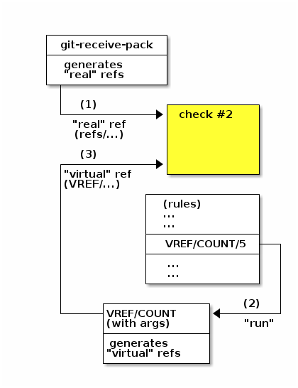

Here's a pictorial representation of what happens, at a very high level, based on the `VREF/COUNT/5` rule in the rule list above.

1. To start with, git-receive-pack calls the update hook with what we will call a "real" ref, something like "refs/heads/master", or "refs/tags/v1.0" -- in general, something that starts with "refs/".

   This ref is sent through "check #2" (please click to refresh your memory if needed).

   Any rules that specify a refex starting with "VREF/" clearly won't match and are ignored in this check.
2. Assuming that check did not fail, the gitolite code in the update hook then starts looking at each "VREF" rule in the rule list that applies to that repo accessed by that user. For each one, it runs the actual VREF program whose name is given in the word after "VREF/". (The rest of the words, if any, along with all sorts of other information, are supplied as arguments).
3. The STDOUT of the called program is captured and any line that starts with the characters "VREF/" is taken as a "**virtual**" ref, and is run through the same "check #2". **The only difference is that, unlike for a regular ref, fallthru does not result in failure, but success.**

### 3.4.2 basic use and understanding

Normally, rules deal with branches and tags (which git collectively calls "refs"). The "ref" is a property of the push which gitolite checks against the set of rules.

"Virtual refs" are other properties of a push that gitolite can be told to check, in addition to the normal ref. For example, "this push has more than 5 changed files" could be one property. Or "this push changed the file called Makefile" could be another. These properties are represented as "virtual refs" that start with "VREF/". (Recall that "normal" refs start with "refs/").

The simplest way to use them is as *additional* "deny" rules to fail a push that might otherwise have passed. This is what the example at the top shows.

It helps to separate VREF rules from normal rules, since no access rule can match both a normal ref and a virtual ref. Here's a good way to structure your rules:

- Put your normal ref rules first. These apply to the branch name or tag name that git itself knows about and sends to gitolite's update hook.

  Fallthru is failure here, which means the ref being pushed **must** match some rule in this set for the push to succeed.
- Put your VREF rules next. These apply to the virtual refs you want to use as additional checks for the push.

  Fallthru is success here, which means the (virtual) ref must be **explicitly denied** in order for the push to fail.

### 3.4.3 advanced use

More complex uses are possible, but may be harder to understand. You may want to experiment with the rules to solidify your understanding as you read this.

#### 3.4.3.1 differences from normal refs

We know where normal refs (like "refs/heads/master" or "refs/tags/v1.0") come from -- they are supplied by git itself when it calls the update hook.

Virtual refs have two differences with normal refs:

- Gitolite has to generate them somehow.
- Fallthru is success, not failure.

Here's some more detail on how it works.

- First, the normal ("real") ref is checked.

  As you already know, the push dies if the ref hits a deny rule **or** it falls through without hitting an allow rule.
- Next, virtual refs are generated and checked one by one.

  We'll talk about the generaton later, but for the check, a virtual ref kills the push *only* if it meets an explicit deny rule ("-"); fallthru does *not* cause failure. Other than that, the checking is done the same way as for a normal ref, viz., as described in the flow for check #2.

#### 3.4.3.2 generating virtual refs

Gitolite uses the VREF rules themselves to help it generate the virtual refs.

Specifically, it looks at each rule that contains a VREF (there are 2 in the above example) and calls a VREF-maker for each of them.

We'll take the COUNT example rule above.

When gitolite sees that rule, it calls the "COUNT" VREF-maker. Specifically, this is the `VREF/COUNT` program (See here for actual locations on disk).

Gitolite passes it the string "5" as an argument (actually, as the *eighth* argument; details later).

The program (which can be written in any language) is expected to do one of two things:

- If the condition is satisfied (i.e., there *are* more than 5 files in this push), it should print `VREF/COUNT/5` to STDOUT.

  You can see that when this virtual ref is processed through the rules, it will encounter the "deny" rule, and thus kill the push.
- Otherwise it should print nothing. That is, there is no virtual ref to run through "check #2", so nothing happens.

It should exit with an exit code of zero in either case.

If it exits with a non-zero, the push dies regardless of what is printed (see "mimicking a plain old update hook" for why this is useful).

### 3.4.4 more details and nuances

#### 3.4.4.1 mimicking a plain old update hook

If the VREF maker exists with a non-zero exit code, then regardless of what it prints or does not, the push dies.

This is just like a plain 'update' hook. Since the first 3 arguments (see later) are also the same that a plain 'update' hook receives, you can actually use any existing update hook as a VREF-maker.

To repurpose an existing update hook as a VREF-maker, just copy it to the VREF directory (again, see here for actual locations on disk). Then add this rule to your repos:

```
repo foo    # or maybe even 'repo @all'
    -   VREF/my-update-hook     =   @all
```

That's it.

#### 3.4.4.2 what if the VREF-maker prints a different virtual ref?

Unless you know what you're upto, don't do that.

But it's allowed and the behaviour is defined. The VREF-maker for the NAME VREF is a good example. It ignores the arguments and just makes VREFs out of the name of every file that was changed in the push.

Here's another example. Consider the problem of not allowing pushes at specific times. Let's say repo 'foo' cannot be pushed between 4 and 7pm, and repo 'bar' can only be pushed before 9am. And of course all this only applies to the junior developers, the poor guys!

In this example, we write the "Hour" VREF-maker to *ignore the argument passed* and just print `VREF/Hour/NN` where NN can be between 00 to 23 inclusive and of course represents the current hour.

If foo is pushed at 6:30pm, the VREF-maker prints VREF/Hour/18, which satisfies the third rule and is rejected.

If bar is pushed at, say, 7:20am, the vref printed is VREF/Hour/07, which does not match any of the rules. And fallthru is success so it passes.

```
repo foo
    RW+                         =   @all

    -   VREF/Hour/16            =   @junior-devs
    -   VREF/Hour/17            =   @junior-devs
    -   VREF/Hour/18            =   @junior-devs

repo bar
    RW+                         =   @all

    -   VREF/Hour/09            =   @junior-devs
    -   VREF/Hour/1[0-9]        =   @junior-devs
    -   VREF/Hour/2[0-9]        =   @junior-devs
```

#### 3.4.4.3 why is fallthru considered success with VREFs

Virtual refs are **best used** (1) as **additional** "deny" rules, performing extra checks that core gitolite cannot. You usually want such extra checks only for some people.

When fallthru is success, you can simply *ignore* all the other users (for whom such additional checks are not needed).

If fallthru were to be considered 'failure', you'd be forced to add a "success rule" like this for *every* virtual ref you used in this repo, in each case listing every user who was not already mentioned in the context of that vref:

```
RW+ VREF/VREFNAME   =   @userlist   # uggh! what a pain!
```

Worse, since every virtual ref involves calling an external program, many of these calls may be wasted.

(1) "best used as..." does not mean "only used as...". For example it's perfectly easy to turn this around if, instead of having a list of people who *do* need extra checks, all you have is the complementary list:

```
RW+ VREF/NAME/Makefile      =   @senior-devs
-   VREF/NAME/Makefile      =   @all
```

#### 3.4.4.4 what if the VREF-maker prints something that's not even a virtual ref?

The VREF-maker can print anything it wants to STDOUT. Lines not starting with `VREF/` are printed as is (so your VREF-maker can do mostly-normal printing to STDOUT). This is especially useful if you've turned an existing update hook into a VREF-maker, and it prints stuff meant for the user, but you don't want to touch the code.

For lines starting with `VREF/`, the first word in each such line will be treated as a virtual ref, while the rest, if any, is a message to be added to the standard "...DENIED..." message that gitolite will print if that refex matches and the rule is a deny rule.

#### 3.4.4.5 in what order are VREF-makers called?

VREF-makers are called in the sequence in which they appear in the conf file.

There are some optimisations to prevent calling the same VREF-maker with the same arguments more than once, and the VREF-maker code for the NAME VREF (which is special) is called only once regardless of how many times it appears but these details should not concern anyone but a developer.

#### 3.4.4.6 what arguments are passed to the vref-maker?

- Arguments **1, 2, 3**: the 'ref', 'oldsha', and 'newsha' that git passed to the update hook (see 'man githooks').

  This, combined with the fact that non-zero exits are detected, mean that you can simply use an existing update.secondary as a VREF-maker as-is, no changes needed.
- Arguments **4 and 5**: the 'oldtree' and 'newtree' SHAs. These are the same as the oldsha and newsha values, except if one of them is all-0. (indicating a ref creation or deletion). In that case the corresponding 'tree' SHA is set (by gitolite, as a courtesy) to the special SHA `4b825dc642cb6eb9a060e54bf8d69288fbee4904`, which is the hash of an empty tree.

  (None of these shenanigans would have been needed if `git diff $oldsha $newsha` would not error out when passed an all-0 SHA.)
- Argument **6**: the attempted access flag. Typically `W` or `+`, but could also be `C`, `D`, or any of these 4 followed by `M`. If you have to ask what they mean, you haven't read enough gitolite documentation to be able to make virtual refs work.
- Argument **7**: is the entire refex; say `VREF/COUNT/3/NEWFILES`.
- Arguments **8 onward**: are the split out (by `/`) portions of the refex, excluding the first two components. In our example they would be `3` followed by `NEWFILES`.

Yes, argument 7 is redundant if you have 8 and 9. It's meant to make it easy to write vref-maker scripts in any language. See script examples in source.

### 3.4.5 VREF-makers shipped with gitolite

#### 3.4.5.1 restricting pushes by dir/file name

The "NAME" VREF allows you to restrict pushes by the names of dirs and files changed. (Side note: the NAME VREF is the only one directly implemented within the update hook, so you won't find it in the VREF directory).

Here's an example. Say you don't want junior developers pushing changes to the Makefile, because it's quite complex:

```
repo foo
        RW+                             =   @senior_devs
        RW                              =   @junior_devs

        -   VREF/NAME/Makefile          =   @junior_devs
```

When a senior dev pushes, the VREF is not invoked at all. But when a junior dev pushes, the VREF is invoked, and it returns a list of files changed **as virtual refs**, looking like this:

```
VREF/NAME/file-1
VREF/NAME/dir-2/file-3
...etc...
```

Each of these refs is matched against the access rules. If one of them happens to be the Makefile, then the ref returned (VREF/NAME/Makefile) will match the deny rule and kill the push.

Another way to use this is when you know what is allowed instead of what is not allowed. Let's say the QA person is only allowed to touch a file called CHANGELOG and any files in a directory called ReleaseNotes:

```
repo foo
        RW+                             =   @senior_devs
        RW                              =   @junior_devs
        RW+                             =   QA-guy

        RW+ VREF/NAME/CHANGELOG         =   QA-guy
        RW+ VREF/NAME/ReleaseNotes/     =   QA-guy
        -   VREF/NAME/                  =   QA-guy
```

#### 3.4.5.2 number of changed or new files

The COUNT VREF is used like this:

```
-   VREF/COUNT/9                    =   @junior-developers
```

In response, if anyone in the user list pushes a commit series that changes more than 9 files, a virtual ref of "VREF/COUNT/9" is returned. Gitolite uses that as a "ref" to match against all the rules, hits the same rule that invoked it, and denies the request.

If the user did not push more than 9 files, the VREF code returns nothing, and nothing happens.

COUNT can take one more argument:

```
-   VREF/COUNT/9/NEWFILES           =   @junior-developers
```

This is the same as before, but have to be more than 9 *new* files not just changed files.

#### 3.4.5.3 advanced filetype detection

Note: this is more for illustration than use; it's rather specific to one of the projects I manage but the idea is the important thing.

Sometimes a file has a standard extension (that cannot be 'gitignore'd), but it is actually automatically generated. Here's one way to catch it:

```
 -   VREF/FILETYPE/AUTOGENERATED     =   @all
```

You can look at `src/VREF/FILETYPE` to see how it handles the 'AUTOGENERATED' option. You could also have a more generic option, like perhaps BINARY, and handle that in the FILETYPE vref too.

#### 3.4.5.4 checking author email

Some people want to ensure that "you can only push your own commits".

If you force it on everyone, this is a very silly idea (see "Philosophical Notes" section of `src/VREF/EMAIL-CHECK`).

But there may be value in enforcing it just for the junior developers.

The neat thing is that the existing `contrib/update.email-check` was just copied to `src/VREF/EMAIL-CHECK` and it works, because VREFs get the same first 3 arguments and those are all that it cares about. (Note: you have to change one subroutine in that script if you want to use it)

#### 3.4.5.5 voting on commits

Although gitolite can't/won't do the whole "code review + workflow enforcement" thing that Gerrit Code Review does, a basic implementation of voting on a commit is surprisingly easy. See src/VREF/VOTES for details (and note that the actual *code* is just 2-3 lines; the rest is inline documentation).

### 3.4.6 other ideas -- code welcome!

#### 3.4.6.1 "no non-merge first-parents"

Shruggar on #gitolite wanted this. Possible code to implement it would be something like this (untested)

```
[ -z "$(git rev-list --first-parent --no-merges $2..$3)" ]
```

This can be implemented using `src/VREF/MERGE-CHECK` as a model. That script does what the 'M' qualifier does in access rules (see last part of this), although the syntax to be used in conf/gitolite will be quite different.

#### 3.4.6.2 other ideas for VREFs

Here are some more ideas:

- Number of commits (`git rev-list --count $old $new`).
- Number of binary files in commit (currently I only know to count occurrences of `Bin` in the output of `git diff --stat`.
- Number of *new* binary files (count `Bin 0 ->` in `git diff --stat` output).
- Time of day/day of week (see example snippet somewhere above).
- IP address.
- Phase of the moon.

Note that pretty much anything that involves `$oldsha..$newsha` will have to deal with the issue that when you push a new tag or branch, the "old" part is all 0's, and unless you consider `--all` existing branches and tags it becomes meaningless in terms of "number of new files" etc.

## 3.5 delegating access control responsibilities

Delegation allows you to divide up a large conf file into smaller groups of repos (called **subconf**s) and hand over responsibility to manage them to **sub-admin**s. Gitolite can prevent one sub-admin from being able to set access rules for any other sub-admin's repos.

Delegation is achieved by combining two gitolite features: subconf and the NAME VREF.

### 3.5.1 example

Here's a sample conf that does delegation:

```
@webbrowsers        = firefox lynx browsers/..*
@webservers         = apache nginx servers/..*
@malwares           = conficker storm ms/..*
    # side note: if anyone objects, we claim ms stands for "metasploit" ;-)

# the admin repo access probably had these 2 lines to start with:
repo gitolite-admin
    RW+                                     = sitaram
# now add these lines to the config for the admin repo
    RW                                      = alice bob mallory
    RW  VREF/NAME/conf/subs/webbrowsers     = alice
    RW  VREF/NAME/conf/subs/webservers      = bob
    RW  VREF/NAME/conf/subs/malwares        = mallory
    -   VREF/NAME/                          = alice bob mallory

# pull in these files using the "subconf" command
subconf "subs/*.conf"
```

If you've read the VREF part, or at least understood how NAME VREFs work, it should be clear that, in terms of changes to the gitolite-admin repo:

- The user sitaram has no restrictins of any kind
- Users alice, bob, and mallory can only touch files within their assigned areas within conf/subs. If they try to change any other file (keydir, conf/gitolite.conf, or something in one of the other sub-admin's areas), then the last rule kicks in and the push gets rejected.

Now all we need is to see what this "subconf" thing is all about.

### 3.5.2 the subconf command

Subconf is exactly like the include command in syntax:

```
subconf "foo.conf"
```

but while reading the included file (as well as anything included from it), gitolite sets the "current subconf name" to "foo".

A "subconf" imposes some restrictions on what repos can be managed.

For example, while the subconf name is "foo", as in the above example, gitolite will only process "repo" lines for:

- A repo called "foo".
- A group called "@foo", as long as the group is defined in the main conf file (i.e., *outside* "foo.conf").
- A member of a group called "@foo" (again, defined outside).
- A repo that matches a member of a group called "@foo" if that member is a regular expression.

Here's an example. If the main conf file contains

```
@foo    =   aa bb cc/..*
```

then the subconf can only accept repo statements that refer to 'foo', '@foo', 'aa', 'bb', or any repo whose name starts with 'cc/'.

**Note**: the subconf name "master" is special; it is the default subconf in effect for the main conf file and has no restrictions.

#### 3.5.2.1 how the "subconf name" is derived

For subconf lines that look just like include statements, i.e.,

```
subconf "foo/bar.conf"
subconf "frob/*.conf"
    # assume frob has files aa.conf, bb.conf
```

the subconf name as each file is being processed is the base name of the file. This means it would be "bar" for the first line, "aa" when processing "frob/aa.conf", and "bb" when processing "frob/bb.conf".

A variation of subconf exists that can explicitly state the subconf name:

```
subconf foo "frob/*.conf"
```

In this variation, regardless of what file in "frob/" is being read, the subconf name in effect is "foo".

### 3.5.3 security notes

#### 3.5.3.1 group names

You can use "@group"s defined in the main config file but do not attempt to redefine or extend them in your own subconf file. If you must extend a group (say `@foo`) defined in the main config file, do this:

```
@myfoo  =   @foo
# now do whatever you want with @myfoo
```

Group names you define in your subconf will not clash even if the exact same name is used in another subconf file, so you need not worry about that.

#### 3.5.3.2 delegating pubkeys

Short answer: not gonna happen.

The delegation feature is meant only for access control rules, not pubkeys. Adding/removing pubkeys is a much more significant event than changing branch level permissions for people already on staff, and only the main admin should be allowed to do it.

Gitolite's "userids" all live in the same namespace. This is unlikely to change, so please don't ask -- it gets real complicated to do otherwise. Allowing sub-admins to add users means username collisions, which also means security problems (admin-A creates a pubkey for Admin-B, thus gaining access to all of Admin-B's stuff).

If you feel the need to delegate even that, please just go the whole hog and give them separate gitolite instances (i.e., running on different servers, or at least under different gitolite hosting users on the same server)!

## 3.6 allowing access to gitweb and git-daemon

> **Note**: The old gitolite (v1.x, v2.x) used to tie itself into knots dealing with gitweb and daemon. One of the goals of v3 was to get out of that game, which your author does not play anyway. This means statements like "...special user called 'gitweb'..." really apply to the non-core programs that gitolite ships with, not to "core" gitolite, and any or all of this functionality can be disabled by commenting out certain lines in the rc file.

> Also, **note** that gitolite does **not** install or configure gitweb/git-daemon -- that is a one-time setup you must do separately.

### 3.6.1 gitweb

The following repos are deemed to be readable by gitweb:

- Any repos readable by the special user `gitweb`.
- Any repos containing one or more of the following types of lines: (actually, any config variable starting with `gitweb.`).

  ```
  config gitweb.owner         =   owner name
  config gitweb.description   =   some description
  config gitweb.category      =   some category
  ```

  Side note: the following shorter forms are available as syntactic sugar for the above longer forms:

  ```
  owner       =   owner name
  desc        =   some description
  category    =   some category
  ```

The list of gitweb-readable repos is written to a file whose name is given by the rc file variable `GITWEB_PROJECTS_LIST`. The default value of this variable, if it is not specified or empty, is `$HOME/projects.list`.

In addition, each of the config variables described above is written to the repo to which it pertains, so that gitweb can use them.

#### 3.6.1.1 changing the UMASK

Gitweb (or cgit, redmine, etc.) typically runs under a different userid, and the default permissions that gitolite sets make them unreadable.

See the section on the `UMASK` variable in the page for the rc file.

#### 3.6.1.2 repo-specific authorisation in gitweb

Gitweb has a feature whereby it will call a (perl) function that you supply, passing it the full path to the repo being accessed. If the remote user is authenticated, the username will be available, so your function can take those two pieces of information and return true or false to allow or deny the repository access.

If you want to use gitolite's access rules in making this determination, you will first have to ensure that the HTTP username (i.e., the username known to apache/gitweb) is the same as the gitolite username. If you're using gitolite's http mode, this is probably already true, but if you're using the more widely used ssh mode, you'll have to make sure they match.

You then need to add this code to your gitweb.conf.

### 3.6.2 git-daemon

Any repo readable by the special user `daemon` is deemed to be readable by git-daemon. For each of these repos, an empty file called `git-daemon-export-ok` is created in the repository (i.e., the `repo.git` directory inside `$HOME/repositories`).

### 3.6.3 tips

Setting descriptions en-masse usually does not make sense, but you can certainly do things like

```
repo @all
    R       =   gitweb daemon
```

assuming you have other means of setting 'gitweb.description' and 'gitweb.owner'.

Also see this for a twist on that.

## 3.7 mirroring using gitolite

**WARNING** v2 gitolite mirroring users please note: **there are significant changes** in syntax and usage compared to v2. If you're not the kind who reads documentation before doing serious system admin things, well... good luck!

### 3.7.1 quick intro

Mirroring is simple: you have one "master" server and one or more "slave" servers. The slaves get updates only from the master; to the rest of the world they are at best read-only.

In the following pictures, each box (A, B, C, ...) is a repo. The master server for a repo is colored red, slaves are green. The **user** pushes to the repo on the master server (red), and the master server -- once the user's push succeeds -- then does a `git push --mirror` to the slaves. The arrows show this mirror push.

The first picture shows what gitolite mirroring used to be like a long time ago (before v2.1, actually). There is exactly one master server; all the rest are slaves. Each slave mirrors **all** the repos that the master carries, no more and no less.

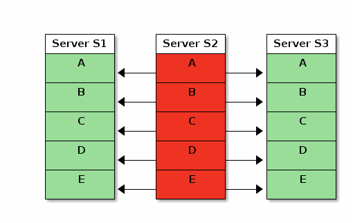

This is simple to understand and manage, and might actually be fine for many small sites. The mirrors are more "hot standby" than anything else.

But when you have 4000+ developers on 500 repos using 25 servers in 9 cities, that single server tends to become a wee bit stressed. Especially when you realise that many projects have highly localised development teams. For example, if most developers for a project are in city X, with perhaps a few in city Y, then having the master server in city Z is... suboptimal :-)

And so, for about 3 years now, gitolite could do this:

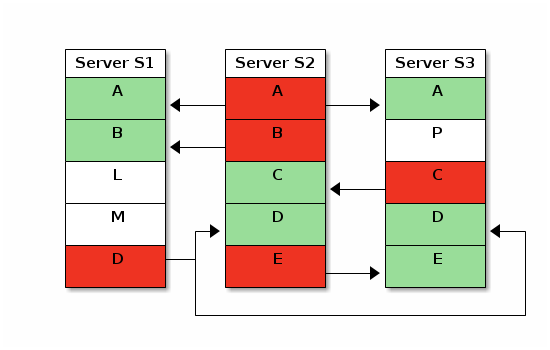

You can easily see the differences in this scenario, but here's a more complete description of what gitolite can do:

- Different masters and sets of slaves for different repos.

  This lets you do things like:
  - Use the server closest to *most* of its developers as the master for that repo.
  - Mirror a repo to only some of the servers.
  - Have repos that are purely local to a server (not mirrored at all).
  - Push to a slave on demand or via cron (helps deal with bandwidth or connectivity constraints).

  All this is possible whether or not the gitolite-admin repo is mirrored -- that is, all servers have the *exact same* gitolite-admin repo or not.
- Pushes to a slave can be transparently forwarded to the real master.

  Your developers need not worry about where a repo's master is -- they just write to their local mirror for *all* repos, even if their local mirror is only a slave for some.

### 3.7.2 caveats

- Mirroring by itself will never *create* a repo on a slave; it has to exist and be prepared to receive updates from the master.

  The simplest way to ensure your repos exist on the slaves also is to mirror the special gitolite-admin repo as well, and this is what most sites do.
- There is limited support for auto-creating wild card repos and sending 'perms' info across, with the following caveats at present. (Some of this text won't make sense unless you know what those features are).
  - *WARNING: it does NOT make sense to mirror wild repos in setups where the authentication data is not the same (i.e., where "alice" on the master and "alice" on a slave maybe totally different people)*.
  - This has only been minimally tested. For example, complex setups or asymmetric configs on master and slave, etc. have NOT been tested.
  - Permission changes will only propagate on the next 'git push'. Of course, if you know the name of the slave server, you can run

    ```
    ssh git@host mirror push slave-server-name repo-name
    ```

  - Using 'perms' on a slave is allowed but will neither propagate nor persist. They will be overwritten by whatever perms the master has (even if it is an empty set) on the next 'git push'.
  - As with lots of extra features in gitolite, smart http support is not on my radar. Don't ask.

  Please test it out and let me know if something surprising happens. Be aware that I have been known to claim bugs are features if I don't have time to fix them immediately :-)
- Mirroring is only for git repos. Ancillary files like gl-creator and gl-perms in the repo directory are not mirrored; you must do that separately. Files in the admin directory (like log files) are also not mirrored.
- If you ever do a bypass push, mirroring will not work. Mirroring checks also will not work -- for example, you can push to a slave, which is not usually a good idea. So don't bypass gitolite if the repo is mirrored!
- From v3.5.3 on, gitolite uses an asynchronous push to the slaves, so that the main push returns immediately, without waiting for the slave pushes to complete. Keep this in mind if you're writing scripts that do a push, and then read one of the slaves immediately -- you will need to add a few seconds of sleep in your script.

### 3.7.3 setting up mirroring

This is in two parts: the initial setup and the rc file, followed by the conf file settings and syntax.

#### 3.7.3.1 the initial setup and the rc file

On **each** server:

- Install gitolite normally. Make clones of the server's 'gitolite-admin' repo on your workstation so you can admin them all from one place.
- Give the server a short, simple, "hostname" and set the HOSTNAME in the rc file (i.e., `~/.gitolite.rc` on the server) to this name, for example 'mars'. *Note: this has nothing to do with the hostname of the server in networking or DNS terms, or in OS terms. This is internal to gitolite*.
- Run ssh-keygen if needed and get an ssh key pair for the server. Copy the public key to a common area and name it after the host, but with 'server-' prefixed. For example, the pubkey for server 'mars' must be stored as 'server-mars.pub'.
- Copy all keys to all the admin repo clones on your workstation and and add them as usual. This is an `O(N^2)` operation ;-)

  You may have guessed that the prefix 'server-' is special, and distinguishes a human user from a mirroring peer.
- Create "host" aliases to refer to all other machines. See here for what/how.

  The host alias for a host (in all other machines' `~/.ssh/config` files) MUST be the same as the `HOSTNAME` in the referred host's `~/.gitolite.rc`. Gitolite mirroring **requires** this consistency in naming; things will NOT work otherwise.

  Normally you should be able to build one common file and append it to all the servers' `~/.ssh/config` files.
- The following **MUST** work for **each pair** of servers that must talk to each other:

  ```
  # on server mars
  ssh phobos info
  # the response MUST start with "hello, server-mars..."
  ```

  Note the exact syntax used; variations like "ssh git@phobos.example.com info" are NOT sufficient. That is why you need the ssh host aliases.

  Check this command from *everywhere to everywhere else*, and make sure you get expected results. **Do NOT proceed otherwise.**
- Setup the gitolite.conf file on all the servers. If the slaves are to be exact copies of the master, you need to do the complete configuration only on the master; the slaves can have just this because on the first push to the master it will update all the slaves anyway:

  ```
      repo gitolite-admin
          RW+     =   some-local-admin

      option mirror.master    =   mars
      option mirror.slaves    =   phobos
  ```

- When that is all done and tested, **enable mirroring** by going through the rc file and uncommenting all the lines mentioning `Mirroring`.
- If you wish to allow your users to run the mirror command remotely (usually *not* required), you need to enable it just like any other command that is not enabled by default; see gitolite commands for how.

#### 3.7.3.2 conf file settings and syntax

Mirroring is defined by the following options. You can have different settings for different repos, and of course some repos may not have any mirror options at all -- they are then purely local.

```
repo foo
    ...access rules...

    option mirror.master        =   mars
    option mirror.slaves        =   phobos deimos
    option mirror.redirectOK    =   all
```

The first line is easy, since a repo can have only one master.

The second is a space separated list of hosts that are all slaves. You can have several slave lists, as long as the config key starts with 'mirror.slaves' and is unique. For example.

```
    option mirror.slaves-1   =   phobos deimos
    option mirror.slaves-2   =   io europa
    option mirror.slaves-3   =   ganymede callisto
```

Do not repeat a key; then only the last line for that key will be effective.

##### 3.7.3.2.1 (v3.6+) preventing automatic sync

Sometimes you don't want a repo to be mirrored automatically (as soon as someone pushes to the master) to all the slaves. For whatever reasons, you have some slaves for whom you would like to trigger the sync later (and you don't mind the fact that those slaves is out of sync until then).

To make that happen, use option lines like this instead of those shown above:

```
    option mirror.slaves.nosync-1   =   phobos deimos
```

Except for the addition of a `.nosync` just after `slaves`, all the other rules are the same as before.

### 3.7.4 (v3.6.1+) mirroring failures

Since mirror pushes happen asynchronously (i.e, the user who originally pushed does not have to wait for the mirrors to be synced), any mirror push failures are not immediately visible to a human being, although you will find them if you look in gitolite's log files.

Therefore, when the output of the mirror push to some slave contains the word "fatal", gitolite saves the output. This saved output is printed to STDERR when any user attempts to clone/fetch/push the repo on the master server for that repo. The hope is that someone will alert an admin to look at the problem. This will continue to happen until the error condition is cleared (i.e., a successful mirror push happens to that specific slave).

If you don't want these unexpected reports confusing users (or programs!), simply create a new rc variable called HUSH_MIRROR_STATUS and set it to 1. (If you're not sure where in the rc file this should go, I suggest putting it right after the HOSTNAME variable).

You can see the mirror status of any repo using the 'mirror status' command; the command line help for the mirror command ('gitolite mirror -h' or 'ssh git@host mirror -h') has details.

### 3.7.5 manually synchronising a slave repo

You can use the `gitolite mirror push` command on a master to manually synchronise any of its slaves. Try it with `-h` to get usage info.

Tip: if you want to do this to all the slaves, try this:

```
for s in `gitolite git-config -r reponame mirror.slave | cut -f3`
do
    gitolite mirror push $s reponame
done
```

This command can also be run remotely; run `ssh git@host mirror -h` for details.

### 3.7.6 redirected pushes

**Please read carefully; there are security implications if you enable this for mirrors NOT under your control**.

Normally, a master, (and *only* a master), pushes to a slave, and the slaves are "read-only" to the users. Gitolite allows a *slave* to receive pushes from a user and transparently redirect them to the *master*.

This simplifies things for users in complex setups, letting them use their local mirror for both fetch and push access to all repos.

The syntax for enabling this is one of these:

```
option mirror.redirectOK    =   all
option mirror.redirectOK    =   phobos deimos
```

The first syntax trusts all valid slaves to redirect user pushes, while the second one trusts only some slaves.

**IMPORTANT NOTES**

- This only works for ssh-based setups; you cannot use this feature in http mode.
- **Authentication** happens on the slave, but **authorisation** is on the master. The master is trusting the slave to authenticate the user correctly, *and* use the same authentication data (i.e., user alice on the slave should be guaranteed to be the same as user alice on the master).
- The part of the authorisation that happens before passing control to git-receive-pack (see the access rules page) will happen on the slave as well.
- You cannot redirect gitolite commands (like perms, etc).

### 3.7.7 appendix A: HOSTNAME substitution

Wherever gitolite sees the word `%HOSTNAME`, it will replace it with the HOSTNAME supplied in the rc file, if one was supplied. This lets you maintain configurations for all servers in one repo, yet have them act differently on different servers, by saying something like:

```
include "%HOSTNAME/*.conf"
```

(See include for more on the 'include' command).

You can use it in other places also, for example:

```
RW+     VREF/NAME/subs/%HOSTNAME/       =   @%HOSTNAME-admins
```

(you still have to define @mars-admins, @phobos-admins, etc., but the actual VREF is now one line instead of one for each server!)

### 3.7.8 appendix B: efficiency versus paranoia

If you're paranoid enough to use mirrors, you should be paranoid enough to set this on each server, despite the possible CPU overhead:

```
git config --global receive.fsckObjects true
```

### 3.7.9 appendix C: moving the admin repo to a different master

Moving only some repos (other than the gitolite-admin repo) to a different master is easy. Just make the change in the gitolite.conf file, add, commit, and push.

Even for the gitolite-admin repo, if the current master is ok, it's the same thing; just make the change and push *to the current master*. Subsequent pushes will go to the new master, of course.

But if the current master is already dead, there's a bit of a catch-22. You can't push to the master because it is dead, and you can't push to any slave because they won't accept updates from anywhere but the server they think is the master.

Here's how to resolve this:

1. On *each* slave:
   - Edit `~/.gitolite/conf/gitolite.conf` to change the master and slave options for the gitolite-admin repo.
   - Run `gitolite setup`.
2. Now clone the admin repo from the *new* master to your workstation, change the options for the rest of the repos (if needed), then add/commit/push.

And that should be all you need to do.

## 3.8 how to setup gitolite to use smart http mode

**Note**: "smart http" refers to the feature that came with git 1.6.6, late 2009 or so. The base documentation for this is `man git-http-backend`. Do **NOT** read `Documentation/howto/setup-git-server-over-http.txt` and think that is the same or even relevant -- that is from 2006 and is quite different (and arguably obsolete).

### 3.8.1 WARNINGS and important notes

- Please read authentication versus authorisation first, and make sure you understand what is gitolite's responsibility and what isn't.
- I have tested this only on stock Fedora (whatever is the current version); YDMV.

### 3.8.2 assumptions:

- Apache 2.x and git installed.
- Httpd runs under the "apache" userid; adjust instructions below if not.
- Similarly for "/var/www" and other file names/locations.

### 3.8.3 instructions

Note that the `GIT_PROJECT_ROOT` variable (see "man git-http-backend") is no longer optional. Make sure you set it to some place outside apache's `DOCUMENT_ROOT`.

In place of detailed instructions, there is a script called `t/smart-http.root-setup`. **Do NOT run this script as is -- it is actually meant for my testing setup and deletes stuff**. However, it does provide an excellent (and working!) narration of what you need to do to install gitolite in smart http mode.

Make a copy of the script, go through it carefully, (possibly removing lines that delete files etc.), change values per your system, and only then run it.

### 3.8.4 allowing unauthenticated access

If you want users to see repos without performing any HTTP authentication, you should first decide what repos they should have unauthenticated access to:

```
repo foo bar baz        # or maybe '@all'?
    R   =   nobody
```

Then in the rc file (`~/.gitolite.rc`), in the section marked "rc variables used by various features", add this (including the trailing comma):

```
HTTP_ANON_USER      =>  'nobody',
```

### 3.8.5 Making repositories available to both ssh and http mode clients

This section has been contributed by Thomas Hager (duke at sigsegv dot at), and is available here.

### 3.8.6 usage

#### 3.8.6.1 client side

Git URLs look like `http://user:password@server/git/reponame.git`.

The custom commands, like "info", "expand" should be handled as follows. The command name will come just after the `/git/`, followed by a `?`, followed by the arguments, with `+` representing a space. Here are some examples:

```
# ssh git@server info
curl http://user:password@server/git/info
# ssh git@server info repopatt
curl http://user:password@server/git/info?repopatt
# ssh git@server info repopatt user1 user2
curl http://user:password@server/git/info?repopatt+user1+user2
```

With a few nice shell aliases, you won't even notice the horrible convolutions here ;-) See t/smart-http for a couple of useful ones.

#### 3.8.6.2 server side

The 'gitolite' command (for example, 'gitolite compile', 'gitolite query-rc', and so on) *can* be run on the server, but it's not straightforward. Assuming you installed exactly as given in this page, you should

- get a shell by using, say, `su -s /bin/bash - apache`
- run `export HOME=$HOME/gitolite-home`
- run `export PATH=$PATH:$HOME/bin`

and *then* you can run `gitolite <subcommand>`

## 3.9 gitolite and the (redis) cache

(requires v3.6.1)

**WARNING: this has not been tested in a while. YMMV**

Gitolite can optionally use the Redis in-memory key-value database for a little speed boost for really large sites.

If you look in the gitolite performance page, you will see, right at the bottom, that pretty much the only thing in gitolite that *may* be slow is the info command. The cache feature fixes that problem :-)

Using Redis as the backend database is actually a bit of overkill; technically this could just as well have been done using a DBM file or SQlite or something like that, but since this is only a *cache*, an in-memory database works out better. However, Redis does have one real advantage: cache timeouts!

Support for this feature is limited to verifiable gitolite bugs, if you find any; I can't help you with redis itself.

### 3.9.1 how does caching work?

To use this feature, just install Redis, then the perl driver "Redis.pm". Install or upgrade Gitolite to the latest master, then uncomment (or add, if it doesn't exist) the following line in the rc file:

```
CACHE       =>  'Redis',
```

If you're *adding* it, please add it within the %RC hash, but outside the ENABLE list. (If in doubt, add it just after the UMASK entry).

Then perform some gitolite operation (anything that requires any form of access checking). Redis should start automatically and the right things should happen; see below if it does not.

### 3.9.2 troubleshooting caching

If you ever kill the redis-server be sure to also remove the socket file `~/.redis-gitolite.sock`. Conversely if you ever remove the sock file be sure to kill the process also. Otherwise you get weird behaviour, including possible hangs. (If things don't seem to work, the first thing to do is to kill all 'redis-server's on that userid and remove `~/.redis-gitolite.*`, then try again.)

**Note**: To the best of my knowledge, this cannot result in wrong data being passed to gitolite, causing a security breach. If anyone has time I'd appreciate a review of the code.

### 3.9.3 caching details

#### 3.9.3.1 what is cached

At present, gitolite caches only one specific function: the "access()" function. This is available from the shell as the 'gitolite access ...' command, as well as from perl via the "Easy.pm" interface; see dev-notes for more. It is easily the "workhorse" of gitolite.

The cache is flushed completely when the gitolite.conf file is "compiled". You might see some things running a bit slower -- at least until things settle down.

Finally, if you run 'perms', the cache entries *for that specific repo* are also flushed.

#### 3.9.3.2 how long is it cached

Redis has a timeout feature that can delete entries after a certain period of time has elapsed since they were created or updated. Gitolite sets a timeout of 90000 seconds (just over a day) normally. However, if you're using the GROUPLIST_PGM feature (see here for details), then this timeout becomes 900 seconds (only 15 minutes). This is because a user's group membership, and thus her access rights, can change without gitolite being aware of the change.

If you're not using the GROUPLIST_PGM feature, you don't have to do anything. But if you are using it, then a cache timeout of 15 minutes may be too much or too little for you -- I cannot judge that. You can tell gitolite what timeout you want for your setup, by adding (or uncommenting) an RC variable called CACHE_TTL; its value is the number of seconds for the timeout.

## 3.10 namespace support in gitolite

*This feature is only available in the 'namespaces' branch until enough people test it and tell me it works fine*.

**AVOID NASTY SURPRISES!** Please read the entire page before attempting to use or install this. Most non-core features of gitolite do not work with namespaces, and, worse, many of them will *fail silently*. There are also security issues you need to be aware of.

### 3.10.1 background

In many projects, developers need to push their work to some central place for others to fetch. Namespaces allow you to give each developer what looks like her own repo or set of repos, while combining all these logical repos into one physical repo on the server. This saves a lot of disk space if they all share a lot of common history.

The logical repos look like normal repos to a git *client*; all the magic is on the server side. (But see the "WARNINGS" section).

### 3.10.2 terminology

There is one repo that is special, and several others that depend upon it or use it. Depending on context, we use one of the following names:

- Storage context: backing repo/real repo, and logical repos
- Workflow context: blessed repo and developer repos

In addition, in the gitolite context you could say that the blessed repo is a normal (not "wild") repo and the logical repos are wild repos, since that is the most convenient way to set this up. However, it is not mandatory -- you can have a wild repo as a backing repo, and/or a normal repo as a logical repo if you wish.

### 3.10.3 setup

First, add the following lines to the rc file, as indicated:

```
# add this line as the *last* item in the PRE_GIT trigger list.  In
# particular, it should be *after* the Mirroring::pre_git line if you're
# using mirroring.
'Namespaces::pre_git',

# add this line as the *first* item in the POST_GIT trigger list.  In
# particular, it should be *before* the Mirroring::post_git line if you're
# using mirroring.
'Namespaces::post_git',
```

Then use the following example conf below as a guide and roll your own. This example is from a mail to the gitolite list by Javier Domingo ("Mirroring forks", 13-11-2012), modified slightly.

```
# backing repos, normal (non-wild), serving as blessed repos
repo    linux git gitolite [...other projects...]
    RW+     =   integration-manager
    R       =   @all

# logical repos, wild, created by devs as needed
repo    CREATOR/[a-zA-Z0-9].*
    C       =   @all
    RW+     =   CREATOR
    R       =   READERS @all
    option namespace.pattern = %/* is @1 in @2
```

### 3.10.4 use

A developer doesn't have to do anything differently. She will still run, e.g., `git clone git@host:alice/linux` to auto-create and clone a wild repo for herself, then add a remote to the "backing" repo, fetch it, start working, and eventually push her work to alice/linux.

However, she might notice some differences. To begin with, her first push of an enormous code base, to what she thought was an empty repo on the server, might go surprisingly fast :)

Secondly, a lot of *gitolite* commands (and other features) won't work. See the "WARNINGS" section below for more.

### 3.10.5 details

The option line above has 3 parts separated by the words "is" and "in":

```
<pattern> is <namespace> in <backing repo>
```

When a user attempts to access a logical repo (say "alice/linux"), the namespace pattern for that repo is applied to the repo name as follows:

- a percent sign matches a single component in the repo name
- an asterisk matches one or more components

Once the matching is done, each "at-digit" combination is replaced by the corresponding matched segment to derive the namespace and the backing repo name.

Some examples may help:

- Here's a simple one that separate the first component from the rest:

  ```
  option namespace.pattern = %/* is @1 in @2
  ```

  A reponame of 'alice/linux' gives you a namespace of 'alice' and a backing reponame of 'linux'. Similarly, 'alice/linux/2.2' gives you 'alice' and 'linux/2.2' (which means a repo of that name has to exist!); notice how the asterisk grabs up all the remaining components in the repo name.
- This one separates the first, the second, and all the rest, but combines them in a different order:

  ```
  option namespace.pattern = %/%/* is @1/@3 in @2
  ```

  A reponame of 'alice/linux/2.2' gives you 'alice/2.2' and 'linux', while a reponame of 'alice/linux/2.2/smp' gives you 'alice/2.2/smp' and 'linux'.
- Here's another example on the same lines:

  ```
  option namespace.pattern = %/%/%/* is @3/@2/@4 in @1
  ```

  A reponame of 'linux/kernel/torvalds/linux-2.6' gives you a namespace of 'torvalds/kernel/linux-2.6' and a backing repo name of 'linux'.
- Here's an interesting example, given in full to explain better. The basic problem is that one of our backing repos is not a simple name (like 'git' or 'linux'); it is 'sitaramc/gitolite'.

  In addition, any developer-owned repo that has 3 or more components is not a fork of anything at all, and should not be subject to namespace processing (i.e., it's just a normal repo)

  ```
      # backing repos
      repo sitaramc/gitolite linux git
      ...access rules for backing repos...
      # logical repos
      repo CREATOR/..*
          C   =   @team
          RW+ =   CREATOR
          R   =   @all
      option namespace.pattern-1 = %/gitolite is @1 in sitaramc/gitolite
      option namespace.pattern-2 = %/% is @1 in @2
      option namespace.pattern-3 = %/%/* is none in @1/@2/@3
  ```

  Firstly, this shows how to specify more than one namespace pattern. Each pattern is tried in *lexically* sorted order until a match is found. (Warning: "lexically sorted" means 'namespace.pattern-10' sorts before 'namespace.pattern-2'!)

  Secondly, the example shows that you can hardcode anything, like we did for the backing reponame in pattern 1.

  Thirdly, it shows how you can specify a pattern that disables namespacing, like the last pattern. When the backing repo name ends up being exactly the same as the original repo name, gitolite notices this and treats it as a real repo, not as a logical repo. (If this confuses you, ignore it and use some other pattern, say `CREATOR/personal/..*` for developers personal repos, and don't give them namespace pattern options).

  Here are some example results from this setup:

  ```
  alice/gitolite              ->  alice, sitaramc/gitolite (pattern 1)
  alice/linux                 ->  alice, linux (pattern 2)
  alice/linux/2.2             ->  (namespace processing disabled)
  alice/personal/foo          ->  (namespace processing disabled)
  ```

- Here's an example with some errors:

  ```
  option namespace.pattern-1 = %/gitolite is @1 in sitaramc/gitolite
  option namespace.pattern-2 = %/% is @1 in @2
  option namespace.pattern-3 = %/%/* is @1/@3 in @2
  ```

  If you try 'alice/gitolite/foo' in this setup, it will only match the 3rd pattern. The backing repo name will be 'gitolite', which probably doesn't exist, and git will complain.

  Also, without rule 3, trying a repo with more than 2 components won't work. Gitolite will complain that no namespace options matched. This would indicate a discrepancy between the `repo [...]` line governing those options and the options themselves; you need to fine tune one or the others to fix things.

### 3.10.6 WARNINGS

#### 3.10.6.1 SECURITY

**First and most important**, please read 'man gitnamespaces' for important security information about namespaces.

Secondly, please note that gitolite's access control decisions are made based on the repo name that the user supplies, even if that is only a logical repo. E.g., in a sequence like this:

```
git clone git@server:alice/linux                        # 1
cd alice
git remote add backing git@server:linux
git fetch backing                                       # 2
git checkout master
git push origin master                                  # 3
```

Lines 1 and 3 use the access list for the logical repo ("alice/linux") to allow or reject a push, while line 2, which is directly contacting the "backing" repo, use that repo's access rules.

In particular, Alice does **not** need write access to the backing repo for the push to succeed!

#### 3.10.6.2 gitolite functionality

Most things you're used to in gitolite won't work with logical repos. From the client point of view, **the only features guaranteed to work on logical repos are**:

- normal git operations (clone, fetch, push)
- creating a new wild repo
- the perms command (except the "-c" flag)

From a server/admin point of view, **the following will not work for logical repos, and may even fail silently!**:

- smart-http mode
- the 'config' line in gitolite.conf
- any 'option's affecting a physical repo, like RepoUmask
- anything that expects to be recorded somewhere in the bare repo directory.
- ...and anything else not explicitly listed as "working" in this doc ;-)

#### 3.10.6.3 gitolite functionality -- mirroring

Mirroring works, but **all the logical repos and the backing repo should have the same mirroring setup**. I.e., which server is the master, who are the slaves, are redirects allowed, if so from where, etc., etc., etc., should all have the same values for all of them. I cannot over-emphasise the importance of this for proper mirroring.

### 3.10.7 other notes

The "backing repo" needs to exist. If it is itself a wild repo, it must be auto-created *before* a logical repo that hangs off of it is accessed.

The logical repo must also be mentioned in the gitolite.conf file in some way, as you saw in the example. Access control decisions are made based on this one, not the backing repo.

One *quirk* is that, if the logical repo is a wild repo, then an actual repo with that name *is* created on disk. Gitolite needs a place to keep its repo-specific permissions so it has to do that. You will find, however, that the objects directory is pretty much empty, even after a lot of activity.

## 3.11 locking binary files

Locking is useful to make sure that binary files (office docs, images, ...) don't get into a merge state. (If you think it's not a big deal, you have never manually merged independent changes to an ODT or something!)

**When git is used in a truly distributed fashion, locking is impossible.** However, in most corporate setups, there is a single central server acting as the canonical source of truth and collaboration point for all developers. In this situation it should be possible to at least prevent commits from being pushed that contains changes to files locked by someone else.

The two "lock" programs (one a command that a user uses, and one a VREF that the admin adds to a repo's access rules) together attempt to achieve this.

Of course, locking by itself is not quite enough. You may still get into merge situations if you make changes in branches. For best results you should actually keep all the binary files in their own branch, separate from the ones containing source code.

### 3.11.1 problem description

Our users are alice, bob, and carol. Our repo is foo. It has some "odt" files in the "doc/" directory. We want to make sure these odt files never get into a "merge" situation.

### 3.11.2 admin/setup

First, someone with shell access to the server must add 'lock' to the ENABLE list in the rc file.

Next, the gitolite.conf file should have something like this:

```
repo foo
    ...other rules...
    -   VREF/lock      =   @all
```

However, see below for the difference between "RW" and "RW+" from the point of view of this feature and adjust permissions accordingly.

### 3.11.3 user view

Here's a summary:

- Any user with "W" permissions to any branch in the repo can "lock" any file. Once locked, no other user can push changes to that file, *in any branch*, until it is unlocked.
- Any user with "+" permissions to any branch in the repo can "break" a lock held by someone else if needed.

For best results, everyone on the team should:

- Switch to the branch containing the binary files when wanting to make a change.
- Run 'git pull' or eqvt, then lock the binary file(s) before editing them.
- Finish the editing task as quickly as possible, then commit, push, and unlock the file(s) so others are not needlessly blocked.
- Understand that breaking a lock require additional, (out of band) communication. It is upto the team's policies what that entails.

### 3.11.4 detailed example

Alice declares her intent to work on "d1.odt":

```
$ git pull
$ ssh git@host lock -l foo doc/d1.odt
```

Similarly Bob starts on "d2.odt"

```
$ git pull
$ ssh git@host lock -l foo doc/d2.odt
```

Carol makes some changes to d2.odt (**without attempting to lock the file or checking to see if it is already locked**) and pushes:

```
$ ooffice doc/d2.odt
$ git add doc/d2.odt
$ git commit -m 'added footnotes to d2 in klingon'
$ git push
<...normal push progress output...>
remote: FATAL: W VREF/lock testing carol DENIED by VREF/lock
remote: 'doc/d2.odt' locked by 'bob'
remote: error: hook declined to update refs/heads/master
To u2:testing
 ! [remote rejected] master -> master (hook declined)
error: failed to push some refs to 'carol:foo'
```

Carol backs out her changes, but saves them away for a "manual merge" later.

```
git reset HEAD^
git stash save 'klingon changes to d2.odt saved for possible manual merge later'
```

Note that this still represents wasted work in some sense, because Carol would have to somehow re-apply the same changes to the new version of d2.odt after pulling it down. **This is because she did not lock the file before making changes on her local repo. Educating users in doing this is important if this scheme is to help you.**

She now decides to work on "d1.odt". However, she has learned her lesson and decides to follow the protocol described above:

```
$ git pull
$ ssh git@host lock -l foo doc/d1.odt
FATAL: 'doc/d1.odt' locked by 'alice' since Sun May 27 17:59:59 2012
```

Oh damn; can't work on that either.

Carol now decides to see what else there may be. Instead of checking each file to see if she can lock it, she starts with a list of what is already locked:

```
$ ssh git@host lock -ls foo

# locks held:

alice   doc/d1.odt      (Sun May 27 17:59:59 2012)
bob     doc/d2.odt      (Sun May 27 18:00:06 2012)

# locks broken:
```

Aha, looks like only d1 and d2 are locked. She picks d3.odt to work on. This time, she starts by locking it:

```
$ ssh git@host lock -l foo doc/d3.odt
$ ooffice doc/d3.odt
<...etc...>
```

Meanwhile, in a parallel universe where d3.odt doesn't exist, and Alice has gone on vacation while keeping d1.odt locked, Carol breaks the lock. Carol can do this because she has RW+ permissions for the repository itself.

However, protocol in this team requires that she get email approval from the team lead before doing this and that Alice be in CC in those emails, so she does that first, and *then* she breaks the lock:

```
$ git pull
$ ssh git@host lock --break foo doc/d1.odt
```

She then locks d1.odt for herself:

```
$ ssh git@host lock -l foo doc/d1.odt
```

When Alice comes back, she can tell who broke her lock and when:

```
$ ssh git@host lock -ls foo

# locks held:

carol   doc/d1.odt      (Sun May 27 18:17:29 2012)
bob     doc/d2.odt      (Sun May 27 18:00:06 2012)

# locks broken:

carol   doc/d1.odt      (Sun May 27 18:17:03 2012)      (locked by alice at Sun May 27 17:59:59 2012)
```

## 3.12 packaging gitolite

Gitolite has broad similarities to git in terms of packaging requirements.

- Git has 150 executables to marshal and put somewhere. Gitolite has the directories `commands`, `lib`, `syntactic-sugar`, `triggers`, and `VREF`.

  It doesn't matter what this directory is. As an example, Fedora keeps git's 150 executables in /usr/libexec/git-core, so /usr/libexec/gitolite may be a good choice; it's upto you.

  *The rest of this section will assume you chose /usr/libexec/gitolite as the location, and that this location contains the 5 directories named above*.
- Git has the `GIT_EXEC_PATH` env var to point to this directory. Gitolite has `GL_BINDIR`. However, in git, the "make" process embeds a suitable default into the binary, making the env var optional.

With that said, here's one way to package gitolite:

- Put the executable `gitolite` somewhere in PATH. Put the executable `gitolite-shell` in /usr/libexec/gitolite (along with those 5 directories).

  Change the 2 assignments to `$ENV{GL_BINDIR}`, one in 'gitolite', one in 'gitolite-shell', to "/usr/libexec/gitolite" from `$FindBin::RealBin`. This is equivalent to "make" embedding the exec-path into the executable.

  **OR**

  Put both executables `gitolite` and `gitolite-shell` also into /usr/libexec/gitolite (i.e., as siblings to the 5 directories mentioned above). Then *symlink* `/usr/libexec/gitolite/gitolite` to some directory in the PATH. Do not *copy* it; it must be a symlink.

  Gitolite will find the exec-path by following the symlink.
- The `Gitolite` subdirectory in `/usr/libexec/gitolite/lib` can stay right there, **OR**, if your distro policies don't allow that, can be put in any directory in perl's `@INC` path (such as `/usr/share/perl5/vendor_perl`).
- Finally, a file called `/usr/libexec/gitolite/VERSION` must contain a suitable version string.

## 3.13 "non-core" gitolite

Much of gitolite's functionality comes from programs and scripts that are not considered "core". This keeps the core simpler, and allows you to enhance gitolite for your own site without too much fuss.

Documentation for non-core gitolite is organised as follows:

- This page describes the types of non-core programs and how/where to install code that is specific to your site.
- The developer notes page tells you how to write your own non-core programs.
- The list of non-core programs talks about what's already shipped with gitolite, with a brief description of each.

### 3.13.1 core versus non-core

Gitolite has five types of non-core code:

- *Commands* can be run from the shell command line. Among those, the ones in the ENABLE list in the rc file can also be run remotely.
- *Hooks* are standard git hooks.
- *Sugar scripts* change the conf language for your convenience. The word sugar comes from "syntactic sugar".
- *Triggers* are to gitolite what hooks are to git. I just chose a different name to avoid confusion and constant disambiguation in the docs.
- *VREFs* are extensions to the access control check part of gitolite.

### 3.13.2 locations...

#### 3.13.2.1 ...for non-core programs shipped with gitolite

`gitolite query-rc GL_BINDIR` will tell you where gitolite's code has been installed. That directory should look like this. Among these, the directories in green are considered "non-core", while the ones in red are considered "core". In addition, the two files "gitolite" and "gitolite-shell" in src are also considered "core"

You might notice that there are two locations for triggers; that is simply because there are two types of them. You might also notice that there is no place for hooks -- gitolite doesn't *ship* with any hooks that are non-core.

```
.
├── commands
├── lib
│   └── Gitolite
│       ├── Conf
│       ├── Hooks
│       ├── Test
│       └── Triggers
├── syntactic-sugar
├── triggers
└── VREF
```

#### 3.13.2.2 ...for *your* non-core programs

If you want to add your own non-core programs, or even *override* the shipped ones with your own, you can.

Put your programs in some convenient directory and use the `LOCAL_CODE` rc variable to tell gitolite where that is. **Please supply the FULL path** to this variable. (You'll find the rc file already has examples lines, commented out, so it's easy to know where to put it and what syntax to use).

Within that directory, you can use any or all of the subdirectories shown here.

If you add a program in your local code directory with the same name as a shipped program, gitolite uses your version.

Notice that there are two directories related to hooks here, neither of which exist in the shipped non-core code. Also, the `hooks/common` directory is a bit special. If you add new hooks to this, you must run `gitolite setup`, or at least `gitolite setup --hooks-only`.

```
.
├── commands
├── hooks
│   └── common
│   └── repo-specific
├── lib
│   └── Gitolite
│       └── Triggers
├── syntactic-sugar
├── triggers
└── VREF
```

#### 3.13.2.3 using the gitolite-admin repo to manage non-core code

**IMPORTANT SECURITY NOTE**

**In this mode, anyone who can push changes to the admin repo will effectively be able to run any arbitrary command on the server.** See gitolite admin and shell access for more background.

The location given in `LOCAL_CODE` could be anywhere on disk, like say `$ENV{HOME}/local`.

However, some administrators find it convenient to use the admin repo to manage this code as well, getting the benefits of versioning them as well as making changes to them without having to log on to the server.

To do this, simply point `LOCAL_CODE` to someplace inside `$GL_ADMIN_BASE` in the rc file. I **strongly** suggest:

```
LOCAL_CODE  =>  "$rc{GL_ADMIN_BASE}/local",
```

Then you create a directory called "local" in your gitolite clone, and create the directory structure (shown in the previous section) within that directory. Thus, when you push the admin repo, the files will land up, with the correct paths, in the location pointed to by LOCAL_CODE.

(Note: when you do this, gitolite takes care of running `gitolite setup --hooks-only` when you change any hooks and push).

### 3.13.3 types of non-core programs

#### 3.13.3.1 gitolite "commands"

Gitolite comes with several commands that users can run. Remote users run commands by saying:

```
ssh git@host command-name [args...]
```

while on the server you can run

```
gitolite command [args...]
```

Very few commands are designed to be run both ways, but it can be done, by checking for the presence of env var `GL_USER`.

All commands respond to a single `-h` option with a suitable message.

You can get a **list of available commands** by using the `help` command. Naturally, a remote user will see a much smaller list than the server user.

You allow a command to be run from remote clients by adding its name to (or uncommenting it if it's already added but commented out) the ENABLE list in the rc file.

#### 3.13.3.2 hooks and gitolite

You can install any hooks except these:

- (all repos) Gitolite reserves the `update` hook. See the "update hook" section in dev-notes if you want additional update hook functionality.
- (gitolite-admin repo only) Gitolite reserves the `post-update` hook.

How/where to install them is described in detail in the "locations" section above, especially this and this. The summary is that you put them in the "hooks/common" sub-directory within the directory whose name is given in the `LOCAL_CODE` rc variable, then run `gitolite setup`.

##### 3.13.3.2.1 repo-specific hooks

**WARNING**: If your site makes a distinction between "right to push the admin repo" and "right to run arbitrary commands on the server" (i.e., if not all of your "admins" have shell access to the server), this is a security risk. If that is the case, **do not enable this feature**.

If you want to add hooks only to specific repos, you can just do it manually if you wish -- just log on to the server and add hooks (except update hook and, for the special gitolite-admin repo, the post-update hook -- touch these and all bets on gitolite's functionality are off).

However, if you want to do that from within gitolite, and thus keep everything together, you can do that also. Here's how.

- Create a directory called `hooks/repo-specific` in whatever location you decided to use for your non-core code (i.e., direct on the server, or within the gitolite-admin repo).
- Add your hooks here, with descriptive names (i.e., not "post-receive", etc., but maybe "jenkins" or "deploy" or whatever).
- Uncomment the 'repo-specific-hooks' line in the rc file or add it to the ENABLE list if it doesn't exist.

  If your rc file does not have an ENABLE list, you need to add this to the POST_COMPILE and the POST_CREATE lists. Click here for more on all this.
- Now add lines like this to your conf file:

  ```
      repo    foo
      option hook.post-receive    =   deploy
  ```

  The syntax should be fairly obvious, but just to be clear, in this case a symlink called "post-receive" will be placed in foo.git/hooks, pointing to the executable called "deploy" in hooks/repo-specific in the local-code area.

  **WARNING**: if the hook already exists, it is silently overwritten.

  **WARNING**: (v3.5.x or below) once the hook is placed, you can't remove it through gitolite. That is, removing the option line won't do anything. You'll have to go to the server and remove it manually.
- (v3.6+) You can assign multiple targets for each hook. For example, you could say

  ```
      repo    foo
      option hook.post-receive    =   deploy mail-admins
  ```

  where "deploy" and "mail-admins" are pieces of code that do whatever their names suggest, and both are, independently, candidates for being run from a post-receive hook.

  When you do this, gitolite does whatever is needed to run each of them as independent post-receive hooks (including sending them info over their STDIN as documented in 'man githooks').

  **For pre-receive or pre-auto-gc you should not use more than one hook. If you really need more than one, ask on the mailing list.**
- (v3.6+) You can change these hooks by saying:

  ```
      repo    foo
      option hook.post-receive    =   deploy mail-admins
  ```

  or delete all of them by saying:

  ```
      repo    foo
      option hook.post-receive    =   ""
  ```

- (v3.6.5+) You can add hooks incrementally. For example:

  ```
      repo    @all
      option hook.post-receive.00 =   mail-admins
      option hook.post-receive.01 =   deploy
      # (and later)
      repo    foo
      option hook.post-receive.00 =   mail-users      #1
      option hook.post-receive.01 =   ""              #2
      # (and maybe still later)
      repo    @foss
      option hook.post-receive.02 =   save-push-sigs
  ```

  Assuming `foo` is a member of `@foss`, this declares 2 post-receive hooks for it: mail-users and save-push-sigs. The suffix (in this example, "00", "01") can actually be any simple word. Using a suffix keeps the option names unique, which allows you to override or delete specific options, as we did in the lines marked '#1' and '#2'. The suffix also determines the order in which the options are used in applying hooks to the repo. If the order doesn't matter to you, just make sure they're unique.

#### 3.13.3.3 syntactic sugar

Sugar scripts help you change the perceived syntax of the conf language. The base syntax of the language is very simple, so sugar scripts take something *else* and convert it into that.

That way, the admin sees additional features (like allowing continuation lines), while the parser in the core gitolite engine does not change.

If you want to write your own sugar scripts, please read the "your own sugar" section in dev-notes first then email me.

You enable a sugar script by uncommenting the feature name in the ENABLE list in the rc file.

#### 3.13.3.4 triggers

Triggers have their own page.

#### 3.13.3.5 VREFs

VREFs also have their own page.

## 3.14 writing your own "non-core" programs

Gitolite has a huge bunch of existing features that gradually need to be moved over. Plus you may want to write your own programs to interact with it.

**This page is about *writing* hooks, commands, triggers, VREFS, and sugar scripts. *Installing* them, including "where and how", is described here**.

Note: the non-core page is the starting point for all information about customising gitolite.

### 3.14.1 environment variables and other inputs

In general, the following environment variables should always be available:

```
GL_BINDIR
GL_REPO_BASE
GL_ADMIN_BASE
```

`GL_BINDIR` is loosely equivalent to GIT_EXEC_PATH in git. `GL_REPO_BASE` is always $HOME/repositories, and `GL_ADMIN_BASE` is $HOME/.gitolite. (You might ask why, if they're fixed values, do we need those variables. Good question... next!)

In addition, commands invoked by a remote client also have `GL_USER`, while hooks have `GL_USER` as well as `GL_REPO` (which is the logical reponame).

A special form of the option syntax can be used to set repo-specific environment variables.

Finally, note that triggers get a lot of relevant information from gitolite as arguments; see here for details.

### 3.14.2 APIs

#### 3.14.2.1 the shell API

The following commands exist to help you write shell scripts that interact easily with gitolite. Each of them responds to `-h` so please run that for more info.

- `gitolite access` to check access rights given repo, user, type of access (R, W, ...) and refname (optional). Example use: src/commands/desc.
- `gitolite creator` to get/check the creator of a repo. Example use: src/commands/desc.
- `gitolite git-config` to check gitolite options or git config variables directly from gitolite's "compiled" output, (i.e., without looking at the actual `repo.git/config` file or using the `git config` command). Example use: src/triggers/post-compile/update-gitweb-access-list.
- `gitolite query-rc` to check the value of an RC variable. Example use: src/commands/desc.

In addition, you can also look at the comments in src/lib/Gitolite/Easy.pm (the perl API module) for ideas.

#### 3.14.2.2 the perl API

...is implemented by Gitolite::Easy; the comments in src/lib/Gitolite/Easy.pm serve as documentation.

Note that some of the perl functions called by Easy.pm will change the current directory to something else, without saving and restoring the directory. Patches (to Easy.pm *only*) welcome.

### 3.14.3 writing your own...

#### 3.14.3.1 ...commands

Commands are standalone programs, in any language you like. They simply receive the arguments you append. In addition, the env var `GL_USER` is available if it is being run remotely. src/commands/desc is the best example at present.

#### 3.14.3.2 ...hooks

##### 3.14.3.2.1 anything but the update hook

If you want to add any hook other than the update hook, 'man githooks' is all you need.

##### 3.14.3.2.2 update hook

If you want to add additional `update` hook functionality, do this:

- Write and test your update hook separately from gitolite.
- Now add the code as a VREF (see here for details). Let's say you called it "foo".

  NOTE: if you don't care about all the extra stuff that VREFs give you over a normal update hook, you don't have to read that page at all; just put the code in the right place and go to the next step.
- To call your new update hook to all accesses for all repos, add this to the end of your conf file:

  ```
      repo @all
          -       VREF/foo        =   @all
  ```

As you probably guessed, you can make your additional update hooks more selective, applying them only to some repos / users / combinations.

Note: a normal update hook expects 3 arguments (ref, old SHA, new SHA). A VREF will get those three, followed by at least 4 more. Your VREF should just ignore the extra args.

#### 3.14.3.3 ...trigger programs

Trigger programs run at specific points in gitolite's execution, with specific arguments being passed to them. See the triggers page for details.

You can write programs that are both manually runnable as well as callable by trigger events, especially if they don't *need* any arguments.

#### 3.14.3.4 ..."sugar"

Syntactic sugar helpers are NOT complete, standalone, programs. They must include a perl sub called `sugar_script` that takes in a listref, and returns a listref. The listrefs point to a list that contains the entire conf file (with all include processing already done). You create a new list with contents modified as you like and return a ref to it.

There are a couple of examples in src/syntactic-sugar.

### 3.14.4 appendix 1: repo-specific environment variables

A special form of the option syntax can be used to set repo-specific environment variables that are visible to gitolite triggers and any git hooks you may install.

For example, let's say you installed a post-update hook that initiates a CI job. By default, of course, this hook will be active for *all* gitolite-managed repos. However, you only want it to run for some specific repos, say r1, r2, and r4.

To do that, first add this to the gitolite.conf:

```
repo r1 r2 r4
    option ENV.CI = 1
```

This creates an environment variable called `GL_OPTION_CI` with the value 1, before any trigger or hook is invoked.

Note: option names *must* start with `ENV.`, followed by a seqence of characters composed of alphas, numbers, and the underscore character.

Now the hook running the CI job can easily decide what to do:

```
# exit if $GL_OPTION_CI is not set
[ -z $GL_OPTION_CI ] && exit

... rest of CI job code as before ...
```

Of course you can also do the opposite; i.e. decide that the listed repos should *not* run the CI job but all other repos should:

```
repo @all
    option ENV.CI = 1

repo r1 r2 r4
    option ENV.CI = ""
```

(The hook code remains the same as before.)

Before this feature was added, you could still do this, by using the `gitolite git-config` command inside the hook code to test for options and configs set for the repo, like:

```
if gitolite git-config -q reponame gitolite-options.option-name
then
    ...
```

The new method is much more convenient, as you can see.

### 3.14.5 appendix 2: log file format

Here's a brief description of gitolite's log file format. All fields are tab separated.

There are two kinds of lines in the log file:

- third field non-empty: actual log lines. These are documented below.
- third field empty (i.e., two tabs after the second field): extra output to help diagnose problems. These are NOT documented and may change without notice. They can be turned off completely by setting the RC variable `LOG_EXTRA` to 0.

For all types of log lines, the first two fields are:

- field 1: local time, in YYYY-MM-DD.HH:MM:SS format
- field 2: transaction ID or "TID". This is actually the PID of the outermost command that was initiated (usually "gitolite-shell"). It helps to keep log lines pertaining to one "run" together, even if several sub-commands are spawned (like for example from triggers, or even the update hook itself).

The third and later fields are all dependent on what type of log line it is.

The various log line formats are:

- **start**

  This line denotes the beginning of a gitolite operation.
  - field 3: 'ssh' or 'http'
  - field 4: `ARGV=<comma-separated list of command line arguments>`

    Usually this is just the gitolite username (the argument to gitolite-shell, as supplied by the forced command in the authorized keys file). If you're giving shell access to some users, this would be "-s,username". That's two command line arguments ("-s" and the username), comma separated.
  - field 5: `SOC=<original command from client>`

    This is the command exactly as the git client sent it, or the user typed it. Typically this is one of these:

    ```
    git-upload-pack 'reponame'
    git-receive-pack 'reponame'
    ```

    (including the single quotes, because that's what the client sent).

    Gitolite commands are also recorded as is, so this could be something like `info` or perhaps `perms -l reponame` etc.
  - field 6: `FROM=<ip address>`
- **pre-git**

  This log line appears when the first access check succeeds (i.e., before git-upload-pack or git-receive-pack is called).
  - field 3: 'pre_git'
  - field 4: reponame
  - field 5: username
  - field 6: 'R' or 'W'
  - field 7: 'any'
  - field 8: the refex that allowed access
- **update**

  This log line appears when the second access check succeeds (i.e., when the update hook decides to allow the push).
  - field 3: 'update'
  - field 4: reponame
  - field 5: username
  - field 6: 'W', '+', 'C', 'D', 'WM', '+M', 'CM', or 'DM'
  - field 7: ref name (like 'refs/heads/master')
  - field 8: old SHA
  - field 9: new SHA
  - field 10: the refex that allowed access

  The values in field 6 reflect the possible write types, but note that there is a difference between what the log file contains and what the gitolite.conf file contains (e.g., `+` versus `RW+`). There's another subtle difference for those who are not thinking clearly: the `RW+` in the conf file is a permission, but it would show up as a `+` in the log file only if an *actual* force push had happened, otherwise it would be just `W`.

  By the way, notice that fields 7 to 9 are exactly what git itself supplies the update hook (see 'man githooks').

  There is a special version of this line that appears when someone bypasses gitolite's access control to push directly on the server. The 'reponame' (field 4) is replaced by the full path of the repo being pushed to, the username (field 5) is replaced by the Unix userid in parentheses, and the operation code (field 6) is 'bypass'.
- **create**

  This log line appears when a wild repo was auto-created by a user.
  - field 3: 'create'
  - field 4: reponame
  - field 5: username
  - field 6: 'R' or 'W'

  Field 6 is 'perms-c' if the wild repo is created using the perms command's '-c' option.
- **end**

  This indicates the end of the transaction. Normally, you should not see any more lines with the same TID after this line.
  - field 3: 'END'
- **warnings** and **errors**

  Typically seen when access is denied.
  - field 3: 'warn' or 'die'
  - field 4: message. Parts of the message (like reponame, username, etc) are not split out into fields, though.
- **cli**

  This logs gitolite sub-commands run directly on the server, like `gitolite setup` etc.
  - field 3: 'cli'
  - field 4: 'gitolite'
  - field 5 to end: arguments supplied to gitolite command, one per field

### 3.14.6 appendix 3: (v3.6.1+) syslog

Gitolite allows you to send log entries to syslog. To do that, uncomment one of the commented out values for LOG_DEST in the rc file. If your rc file does not have any such lines, add one of the following lines just after the LOG_EXTRA line:

```
# use this to log only to syslog
LOG_DEST                        => 'syslog',

# use this to log to syslog and the normal gitolite log
LOG_DEST                        => 'syslog,normal',
```

Please note:

- The first two fields described in the previous section (time, TID) are different. Syslog takes care of putting in the time, and the TID is appended to the ident, so instead of just 'gitolite', you get 'gitolite[$GL_TID]'.

  This means actual log lines will look something like this, since syslog appends the actual PID to the ident as well:

  ```
  Jun  3 09:26:11 sita-lt gitolite[14950][14950]: ssh ARGV=admin  SOC=git-receive-pack 'gitolite-admin'   FROM=::1
  Jun  3 09:26:11 sita-lt gitolite[14950][14950]: pre_git gitolite-admin  admin   W   any refs/.*
  Jun  3 09:26:11 sita-lt gitolite[14950][14991]: update  gitolite-admin  admin   W   refs/heads/master   [snip]
  Jun  3 09:26:13 sita-lt gitolite[14950][14950]: END
  ```

- Normal log messages use the 'info' priority, while LOG_EXTRA messages (see previous section) use the 'debug' priority.

  It may be useful to send the debug output to a different output file. Unlike in the normal gitolite logs, where there is an extra tab character (or, an empty field, depending on how you look at it), the syslog lines do not let you easily distinguish between the main log lines and the LOG_EXTRA lines.

## 3.15 gitolite triggers

Gitolite runs trigger code at several different times. The features you enable in the rc file determine what commands to run (or functions in perl modules to call) at each trigger point. Example of trigger points are "INPUT", "PRE_GIT", "POST_COMPILE", etc.; the full list is examined later in this page.

Quick tip: triggers are to gitolite what hooks are to git; we simply use a different name to avoid constantly having to clarify which hooks we mean! The other difference in gitolite is that each trigger runs multiple pieces of code, not just one program with the same name as the hook, like git does.)

### 3.15.1 types of trigger programs

There are two types of trigger programs. Standalone scripts are placed in triggers or its subdirectories. Such scripts are quick and easy to write in any language of your choice.

Triggers written as perl modules are placed in lib/Gitolite/Triggers. Perl modules have to follow some conventions (see some of the shipped modules for ideas) but the advantage is that they can set environment variables and change the argument list of the gitolite-shell program that invokes them.

If you intend to write your own triggers, it's a good idea to examine a default install of gitolite, paying attention to:

- the path names in various trigger lists in the rc file,
- corresponding path names in the src/ directory in gitolite source, and
- and for perl modules, the package names and function names within.

### 3.15.2 manually firing triggers

It's easy to manually fire triggers from the server command line. For example:

```
gitolite trigger POST_COMPILE
```

However if the triggered code depends on arguments (see next section) this won't work. (The `POST_COMPILE` trigger programs all just happen to not require any arguments, so it works).

### 3.15.3 common arguments

Triggers receive the following arguments:

1. Any arguments mentioned in the rc file (for an example, see the renice command).
2. The name of the trigger as a string (example, `"POST_COMPILE"`), so you can call the same program from multiple triggers and it can know where it was called from.
3. And finally, zero or more arguments specific to the trigger, as given in the next section.

### 3.15.4 trigger-specific arguments and other details

Here are the **rest of** the arguments for each trigger, plus a brief description of when the trigger runs. (Note that when the repo name is passed in as an argument, it is without the '.git' suffix).

- `INPUT` runs before pretty much anything else. INPUT trigger scripts *must* be in perl, since they manipulate the arguments and the environment of the 'gitolite-shell' program itself. Most commonly they will read/change `@ARGV`, and/or `$ENV{SSH_ORIGINAL_COMMAND}`.

  There are certain conventions to adhere to; please see some of the shipped samples or ask me if you need help writing your own.
- `ACCESS_1` runs after the first access check. Extra arguments:
  - repo
  - user
  - 'R' or 'W'
  - 'any'
  - result (see notes below)

  'result' is the return value of the access() function. If it contains the uppercase word "DENIED", the access was rejected. Otherwise it is the refex that caused the access to succeed.

  *Please note that if access is rejected, gitolite-shell will die as soon as it returns from the trigger*.
- `ACCESS_2` runs after the second access check, which is invoked by the update hook to check the ref. Extra arguments:
  - repo
  - user
  - any of W, +, C, D, WM, +M, CM, DM
  - the ref being updated (e.g., 'refs/heads/master')
  - result
  - old SHA
  - new SHA

  `ACCESS_2` also runs on each VREF that gets checked. In this case the "ref" argument will start with "VREF/", and the last two arguments won't be passed.

  'result' is similar to `ACCESS_1`, except that it is the *update hook* which dies as soon as access is rejected for the ref or any of the VREFs. Control then returns to git, and then to gitolite-shell, so the `POST_GIT` trigger *will* run.
- `PRE_GIT` and `POST_GIT` run just before and after the git command. Extra arguments:
  - repo
  - user
  - 'R' or 'W'
  - 'any'
  - the git command ('git-receive-pack', 'git-upload-pack', or 'git-upload-archive') being invoked.

  **NOTE** that the `POST_GIT` trigger has no way of knowing if the push succeeded, because 'git-shell' (or maybe 'git-receive-pack', I don't know) exits cleanly even if the update hook died.
- `PRE_CREATE` and `POST_CREATE` run just before and after a new repo is created. In addition, any command that creates a repo (like 'fork') or potentially changes permissions (like 'perms') may choose to run `POST_CREATE`.

  Extra arguments for normal repo creation (i.e., by adding a "repo foo" line to the conf file):
  - repo

  Extra arguments for wild repo creation:
  - repo
  - user
  - invoking operation
    - 'R' for fetch/clone/ls-remote, 'W' for push
    - can also be anything set by the command running the trigger (e.g., see the perms and fork commands). This lets the trigger code know how it was invoked.
- `POST_COMPILE` runs after an admin push has successfully "compiled" the config file. By default, the next thing is to update the ssh authkeys file, then all the 'git-config's, gitweb access, and daemon access.

  No extra arguments.

### 3.15.5 adding your own scripts to a trigger

Note: for gitolite v3.3 or less, adding your own scripts to a trigger list was simply a matter of finding the trigger name in the rc file and adding an entry to it. Even for gitolite v3.4 or higher, if your rc file was created before v3.4, *it will continue to work, and you can continue to add triggers to it the same way as before*.

The rc file (from v3.4 on) does not have trigger lists; it has a simple list of "features" within a list called "ENABLE" in the rc file. Simply comment out or uncomment appropriate entries, and gitolite will *internally* create the trigger lists correctly.

This is fine for triggers that are shipped with gitolite, but does present a problem when you want to add your own.

Here's how to do that: Let's say you wrote yourself a trigger script called 'foo', to be invoked from the `POST_CREATE` trigger list. To do that, just add the following to the rc file, just before the ENABLE section:

```
POST_CREATE                 =>
    [
        'foo'
    ],
```

Since the ENABLE list pulls in the rest of the trigger entries, this will be *effectively* as if you had done this in a v3.3 rc file:

```
POST_CREATE                 =>
    [
        'foo',
        'post-compile/update-git-configs',
        'post-compile/update-gitweb-access-list',
        'post-compile/update-git-daemon-access-list',
    ],
```

As you can see, the 'foo' gets added to the top of the list.

#### 3.15.5.1 displaying the resulting trigger list

You can use the 'gitolite query-rc' command to see what the trigger list actually looks like. For example:

```
gitolite query-rc POST_CREATE
```

### 3.15.6 tips and examples

1. If you have code that latches onto more than one trigger, collecting data (such as for logging), then the outputs may be intermixed. You can record the value of the environment variable `GL_TID` to tie together related entries.

   The documentation on the log file format has more on this.
2. If you look at CpuTime.pm, you'll see that it's `input()` function doesn't set or change anything, but does set a package variable to record the start time. Later, when the same module's `post_git()` function is invoked, it uses this variable to determine elapsed time.

   *(This is a very nice and simple example of how you can implement features by latching onto multiple events and sharing data to do something)*.
3. You can even change the reponame the user sees, behind his back. Alias.pm handles that.
4. Finally, as an exercise for the reader, consider how you would create a brand new env var that contains the *comment* field of the ssh pubkey that was used to gain access, using the information here.

## 3.16 non-core features shipped with gitolite

**Important Notes on "non-core" features**:

1. The "non-core" gitolite page is the starting point for all information about ... non-core gitolite :)
2. This page decribes many of the non-core features that come with gitolite. If a non-core feature is shipped with gitolite, but information about it is not found in this page, it can be found within the source code; please look there.

   Commands, however, have some extra magic, which is not available to the other types of non-core programs:
   - Running the command with a single `-h` option (i.e., `gitolite <command> -h` or `ssh git@host <command> -h`), will display a suitable message. Please report a bug to me if one of them doesn't.
   - Running 'help', (either as `gitolite help` on the server, or `ssh git@host help` remotely), will give you a list of commands you are allowed to run.
3. Non-core code is **meant** to be localised for your site if you don't like what the shipped version does. You can even maintain it within your gitolite-admin repo if you wish.

### 3.16.1 commands

This is a list of commands that are available in gitolite, with brief descriptions and, if available, a link to more detailed information. Note that in most cases running it with `-h` will give you enough to work with.

Also note that not all of these commands are available remotely.

(The more common/important commands are in bold).

- *access* -- print or test access rights for repo/user
- *config* (v3.6.3+) -- allow limited remote use of 'git config'
- *create* -- create a wild repo
- *creator* -- print or test creator name for wild repo
- *D* -- lets you *D*elete wild repos created using the *C* permission :)
- **desc** -- show/set description for wild repo
- *fork* -- fork a repo on the server. This uses the `-l` option to git clone, so it runs really fast
- *git-config* -- print (or text existence of) 'config' values in the repo. (Don't forget that `option foo.bar = 1` is merely syntactic sugar for `config gitolite-options.foo.bar = 1`, so this can be used to query gitolite options also
- **help** -- see note 1 at the top of this page
- *htpasswd* -- sets your htpasswd
- **info** -- print git/gitolite version, list repos you have access to
- *lock* -- lock binary files for exclusive use (in combination with the 'lock' VREF)
- *mirror* -- manually mirror a repo to a slave
- *motd* (v3.6.1+) -- set/remove a message of the day, per repo or for the whole system
- *option* (v3.6.3+) -- allow repo owner to set options for a repo
- **perms** -- list or set permissions for wild repo
- *push* -- push a gitolite repo locally, bypassing gitolite
- *readme* (v3.6.1+) -- show, remove or set the README.html file for repo.
- *rsync* -- resumable downloads of git bundles (bundles are auto-created as needed)
- *sshkeys-lint* -- look for potential problems in ssh keys
- *sskm* -- self-service key management
- *sudo* -- allows an admin (i.e., someone who has push rights to the 'gitolite-admin' repo) to run any remote command as some other user. This is useful, for example, when a user claims he is unable to access a repo, and you need to check the 'info' output for him, etc. However, it does not work the other way, sorry!
- *symbolic-ref* -- run `git symbolic-ref` on a repo, remotely
- *who-pushed* -- determine who pushed a given commit
- *writable* -- disable/enable writes to specific repo (or all repos, if you're an admin)